# 最新R语言版本：玩转数据处理120题 附多重解法，要点摘要……

陈志明

2024-10-11

可以自信的讲是全网最新最全的R语言版本内容了。

补充说明：

1.绝大部分函数来自tidyverse系列包；

2.对部分题目，认为有必要多种方法计算时，提供了不同的方法，其中包括自编函数或调用已有包函数；

3.个别题目进行了简要的扩展；

4.总体看来，这套题目不难，适合数据分析处理入门练手。

导入必要的包

```r
library(tidyverse)
```

# 1 创建dataframe

data = {“grammer”:[“Python”,“C”,“Java”,“GO”,np.nan,“SQL”,“PHP”,“Python”], “score”:[1,2,np.nan,4,5,6,7,10]}

## 1.1 方法1

```r
df <- data.frame(grammer = c("Python","C","Java","GO",NA,"SQL","PHP","Python"),
                 score = c(1,2,NA,4,5,6,7,10))
df
```

```
##   grammer score
## 1  Python     1
## 2       C     2
## 3    Java    NA
## 4      GO     4
## 5    <NA>     5
## 6     SQL     6
## 7     PHP     7
## 8  Python    10
```

## 1.2 方法2

```r
df_2 <- tibble(grammer = c("Python","C","Java","GO",NA,"SQL","PHP","Python"),
                 score = c(1,2,NA,4,5,6,7,10))
df_2
```

```
## # A tibble: 8 × 2
##   grammer score
##   <chr>   <dbl>
## 1 Python      1
## 2 C           2
## 3 Java       NA
## 4 GO          4
## 5 <NA>        5
## 6 SQL         6
## 7 PHP         7
## 8 Python     10
```

# 2 提取含有字符串”Python”的行

字面意思理解，这里的`含有Python`,应该不是简单的等于，而是字符里包含。比如换成Java，那么Javascript 的行也应该被计算在内。

## 2.1 方法1：理解为`等于python`的做法

```r
# 理解为等于的做法
df_2 %>%
    filter(grammer =="Python")
```

```
## # A tibble: 2 × 2
##   grammer score
##   <chr>   <dbl>
## 1 Python      1
## 2 Python     10
```

## 2.2 方法2：理解为`包含python`的做法

```r
df_2 %>%
    filter(str_detect(grammer,"Python"))
```

```
## # A tibble: 2 × 2
##   grammer score
##   <chr>   <dbl>
## 1 Python      1
## 2 Python     10
```

# 3 输出df的列名

```r
names(df_2)
```

```
## [1] "grammer" "score"
```

或者

```r
colnames(df_2)
```

```
## [1] "grammer" "score"
```

# 4 修改第二列列名为’popularity’

```r
df_2 <- df_2 %>%
    rename(popularity = score)
```

# 5 统计grammer列中每种编程语言出现的次数

```r
df_2 %>%
    count(grammer)
```

```
## # A tibble: 7 × 2
##   grammer     n
##   <chr>   <int>
## 1 C           1
## 2 GO          1
## 3 Java        1
## 4 PHP         1
## 5 Python      2
## 6 SQL         1
## 7 <NA>        1
```

# 6 将空值用上下值的平均值填充

```r
 row_na <- which(is.na(df_2$popularity))

 value4na <-  mean(c(df_2$popularity[row_na+1],
                     df_2$popularity[row_na-1]))

 df_2$popularity <- replace_na(df_2$popularity,
                               value4na)
 df_2
```

```
## # A tibble: 8 × 2
##   grammer popularity
##   <chr>        <dbl>
## 1 Python           1
## 2 C                2
## 3 Java             3
## 4 GO               4
## 5 <NA>             5
## 6 SQL              6
## 7 PHP              7
## 8 Python          10
```

# 7 提取popularity列中值大于3的行

```r
df_2 %>%
filter(popularity > 3)
```

```
## # A tibble: 5 × 2
##   grammer popularity
##   <chr>        <dbl>
## 1 GO               4
## 2 <NA>             5
## 3 SQL              6
## 4 PHP              7
## 5 Python          10
```

# 8 按照grammer列进行去除重复值

```r
df_2 %>%
    dplyr::distinct(grammer)
```

```
## # A tibble: 7 × 1
##   grammer
##   <chr>
## 1 Python
## 2 C
## 3 Java
## 4 GO
## 5 <NA>
## 6 SQL
## 7 PHP
```

# 9 计算popularity列平均值

## 9.1 使用summarise函数

```r
df_2 %>%
    summarise(mean = mean(popularity))
```

```
## # A tibble: 1 × 1
##    mean
##   <dbl>
## 1  4.75
```

## 9.2 直接使用mean()函数

```r
mean(df_2$popularity)
```

```
## [1] 4.75
```

# 10 将grammer列转换为list

```r
grammer_list = as.list(df_2$grammer)

grammer_list
```

```
## [[1]]
## [1] "Python"
##
## [[2]]
## [1] "C"
##
## [[3]]
## [1] "Java"
##
## [[4]]
## [1] "GO"
##
## [[5]]
## [1] NA
##
## [[6]]
## [1] "SQL"
##
## [[7]]
## [1] "PHP"
##
## [[8]]
## [1] "Python"
```

# 11 将DataFrame保存为EXCEL

```r
xlsx::write.xlsx(df_2,
                 file = "df_2.xlsx",
                 sheetName = "df_2" )
```

# 12 查看数据行列数

```r
dim(df_2)
```

```
## [1] 8 2
```

# 13 提取popularity列值大于3小于7的行

```r
df_2 %>%
    filter(popularity > 3 & popularity < 7)
```

```
## # A tibble: 3 × 2
##   grammer popularity
##   <chr>        <dbl>
## 1 GO               4
## 2 <NA>             5
## 3 SQL              6
```

# 14 交换两列位置

## 14.1 方法1:使用dplyr::select()函数

```r
df_2 %>%
    dplyr::select(2,1)
```

```
## # A tibble: 8 × 2
##   popularity grammer
##        <dbl> <chr>
## 1          1 Python
## 2          2 C
## 3          3 Java
## 4          4 GO
## 5          5 <NA>
## 6          6 SQL
## 7          7 PHP
## 8         10 Python
```

## 14.2 方法2:使用dplyr::relocate()函数

```r
df_2 %>%
    dplyr::relocate(2)
```

```
## # A tibble: 8 × 2
##   popularity grammer
##        <dbl> <chr>
## 1          1 Python
## 2          2 C
## 3          3 Java
## 4          4 GO
## 5          5 <NA>
## 6          6 SQL
## 7          7 PHP
## 8         10 Python
```

# 15 提取popularity列最大值所在行

## 15.1 方法1:使用dplyr::filter()函数

```r
 df_2 %>%
    dplyr::filter(popularity == max(popularity))
```

```
## # A tibble: 1 × 2
##   grammer popularity
##   <chr>        <dbl>
## 1 Python          10
```

## 15.2 方法2:使用基础包 which.max()函数

```r
 df[which.max(df_2$popularity),]
```

```
##   grammer score
## 8  Python    10
```

# 16 查看最后5行数据

```r
tail(df_2,5)
```

```
## # A tibble: 5 × 2
##   grammer popularity
##   <chr>        <dbl>
## 1 GO               4
## 2 <NA>             5
## 3 SQL              6
## 4 PHP              7
## 5 Python          10
```

# 17 删除最后一行数据

## 17.1 方法1：使用nrow()定位数据框行数值

```r
df_2 %>%
    slice(1:(nrow(.)-1))
```

```
## # A tibble: 7 × 2
##   grammer popularity
##   <chr>        <dbl>
## 1 Python           1
## 2 C                2
## 3 Java             3
## 4 GO               4
## 5 <NA>             5
## 6 SQL              6
## 7 PHP              7
```

## 17.2 方法2：使用n()定位数据框行数值

```r
df_2 %>%
    slice(1:n()-1)
```

```
## # A tibble: 7 × 2
##   grammer popularity
##   <chr>        <dbl>
## 1 Python           1
## 2 C                2
## 3 Java             3
## 4 GO               4
## 5 <NA>             5
## 6 SQL              6
## 7 PHP              7
```

# 18 添加一行数据

[‘Perl’,6.6] grammer popularity

## 18.1 方法1：使用base R rbind()函数

```r
df_2 %>% rbind(tibble(grammer = "Perl",
                      popularity = 6.6))
```

```
## # A tibble: 9 × 2
##   grammer popularity
##   <chr>        <dbl>
## 1 Python         1
## 2 C              2
## 3 Java           3
## 4 GO             4
## 5 <NA>           5
## 6 SQL            6
## 7 PHP            7
## 8 Python        10
## 9 Perl           6.6
```

## 18.2 方法2：使用dplyr::bind_rows()函数

```r
df_2 %>% dplyr::bind_rows(tibble(grammer = "Perl",
                                popularity = 6.6))
```

```
## # A tibble: 9 × 2
##   grammer popularity
##   <chr>        <dbl>
## 1 Python         1
## 2 C              2
## 3 Java           3
## 4 GO             4
## 5 <NA>           5
## 6 SQL            6
## 7 PHP            7
## 8 Python        10
## 9 Perl           6.6
```

## 18.3 方法3：使用tibble::add_row()函数

该函数可设置加入行的位置。比如，这里我们将加入的Perl 放在第一行

```r
df_17<- df_2 %>%
    add_row(grammer = "Perl",
            popularity = 6.6,.before = 1)
df_17
```

```
## # A tibble: 9 × 2
##   grammer popularity
##   <chr>        <dbl>
## 1 Perl           6.6
## 2 Python         1
## 3 C              2
## 4 Java           3
## 5 GO             4
## 6 <NA>           5
## 7 SQL            6
## 8 PHP            7
## 9 Python        10
```

# 19 对数据按照”popularity”列值的大小进行排序

```r
df_17 %>%
    arrange(-popularity)# 由大到小
```

```
## # A tibble: 9 × 2
##   grammer popularity
##   <chr>        <dbl>
## 1 Python        10
## 2 PHP            7
## 3 Perl           6.6
## 4 SQL            6
## 5 <NA>           5
## 6 GO             4
## 7 Java           3
## 8 C              2
## 9 Python         1
```

## 19.2 方法2：arrange()函数,该函数默认从小到大排序，也可以使用desc()函数

```r
df_17 %>%
    arrange(desc(popularity))# 由大到小
```

```
## # A tibble: 9 × 2
##   grammer popularity
##   <chr>        <dbl>
## 1 Python        10
## 2 PHP            7
## 3 Perl           6.6
## 4 SQL            6
## 5 <NA>           5
## 6 GO             4
## 7 Java           3
## 8 C              2
## 9 Python         1
```

## 19.3 方法3：base R order()函数

```r
df_17[order(-df_17$popularity),]# 由大到小
```

```
## # A tibble: 9 × 2
##   grammer popularity
##   <chr>        <dbl>
## 1 Python        10
## 2 PHP            7
## 3 Perl           6.6
## 4 SQL            6
## 5 <NA>           5
## 6 GO             4
## 7 Java           3
## 8 C              2
## 9 Python         1
```

# 20 统计grammer列每个字符串的长度

```r
df_20 <- df_17 %>%
mutate(charlen = str_length(grammer))

df_20
```

```
## # A tibble: 9 × 3
##   grammer popularity charlen
##   <chr>        <dbl>   <int>
## 1 Perl           6.6       4
## 2 Python         1         6
## 3 C              2         1
## 4 Java           3         4
## 5 GO             4         2
## 6 <NA>           5        NA
## 7 SQL            6         3
## 8 PHP            7         3
## 9 Python        10         6
```

# 21 读取本地EXCEL数据

```r
df <- xlsx::read.xlsx(file = "./data/pandas120.xlsx",
                      sheetName = "Sheet1")
```

## 21.1 查看df数据前5行

```r
head(df,5)
```

```
##            createTime education  salary
## 1 2020-03-16 11:30:18      本科 20k-35k
## 2 2020-03-16 10:58:47      本科 20k-40k
## 3 2020-03-16 10:46:39      不限 20k-35k
## 4 2020-03-16 10:45:44      本科 13k-20k
## 5 2020-03-16 10:20:41      本科 10k-20k
```

# 22 将salary列数据转换为最大值与最小值的平均值

这题的解法挺多，下面几个例子用到了tidyverse系列几个常用包的高频使用函数。

## 22.1 方法1:正则表达式提取数字，并数字化，然后求均值

```r
df_23_1 <- df %>%
    rowwise() %>%
    mutate(salary =  str_extract_all(salary,
                                     "\\d+") %>%
    unlist() %>%
    as.numeric() %>%
    mean()*1000 %>%
        unlist()) %>%
    ungroup()

df_23_1
```

```
## # A tibble: 135 × 3
##    createTime          education salary
##    <dttm>              <chr>      <dbl>
##  1 2020-03-16 11:30:18 本科       27500
##  2 2020-03-16 10:58:47 本科       30000
##  3 2020-03-16 10:46:39 不限       27500
##  4 2020-03-16 10:45:44 本科       16500
##  5 2020-03-16 10:20:41 本科       15000
##  6 2020-03-16 10:33:47 本科       14000
##  7 2020-03-16 10:11:54 硕士       23000
##  8 2020-03-16 09:49:11 本科       12500
##  9 2020-03-16 09:25:47 不限        7000
## 10 2020-03-16 09:35:50 本科       16000
## # ℹ 125 more rows
```

##方法2:分解列，然后再解析数字求均值;

使用到 separate()函数，parse_number()函数以及rowwise()函数。

```r
df_23_2 <-  df %>%
     tidyr::separate(salary,into = c("low",
                                     "high"),
                     sep = "-") %>%
    mutate(salary =1000* ((parse_number(low )+
                           parse_number( high)))/2)
df_23_2
```

```
##              createTime education low high salary
## 1   2020-03-16 11:30:18      本科 20k  35k  27500
## 2   2020-03-16 10:58:47      本科 20k  40k  30000
## 3   2020-03-16 10:46:39      不限 20k  35k  27500
## 4   2020-03-16 10:45:44      本科 13k  20k  16500
## 5   2020-03-16 10:20:41      本科 10k  20k  15000
## 6   2020-03-16 10:33:47      本科 10k  18k  14000
## 7   2020-03-16 10:11:54      硕士 16k  30k  23000
## 8   2020-03-16 09:49:11      本科 10k  15k  12500
## 9   2020-03-16 09:25:47      不限  6k   8k   7000
## 10  2020-03-16 09:35:50      本科 12k  20k  16000
## 11  2020-03-16 10:34:19      本科 15k  25k  20000
## 12  2020-03-16 09:30:40      本科  8k  12k  10000
## 13  2020-03-16 11:30:17      本科 20k  40k  30000
## 14  2020-03-16 10:54:56      本科 20k  30k  25000
```

[output cut: 121 more lines]

##方法3: 方法2的基础上，使用mean()函数，前面加个rowwise()函数

```r
df_23_3 <-  df %>%
     tidyr::separate(salary,
                     into = c("low","high"),
                     sep = "-") %>%
       rowwise() %>%
    mutate(salary = 1000*mean(c(parse_number(low),
                           parse_number(high)
                           )
                         )
           ) %>%
    ungroup()

df_23_3
```

```
## # A tibble: 135 × 5
##    createTime          education low   high  salary
##    <dttm>              <chr>     <chr> <chr>  <dbl>
##  1 2020-03-16 11:30:18 本科      20k   35k    27500
##  2 2020-03-16 10:58:47 本科      20k   40k    30000
##  3 2020-03-16 10:46:39 不限      20k   35k    27500
##  4 2020-03-16 10:45:44 本科      13k   20k    16500
##  5 2020-03-16 10:20:41 本科      10k   20k    15000
##  6 2020-03-16 10:33:47 本科      10k   18k    14000
##  7 2020-03-16 10:11:54 硕士      16k   30k    23000
##  8 2020-03-16 09:49:11 本科      10k   15k    12500
##  9 2020-03-16 09:25:47 不限      6k    8k      7000
## 10 2020-03-16 09:35:50 本科      12k   20k    16000
## # ℹ 125 more rows
```

## 22.2 方法4: 用map函数进行循环处理

```r
 df_23_4 <- df %>%
    mutate(salary = salary %>%
               map(\(x) str_extract_all(x,"\\d+") %>%
    unlist() %>%
    as.numeric() %>%
    mean()*1000) %>%
        unlist())
 df_23_4
```

```
##              createTime education salary
## 1   2020-03-16 11:30:18      本科  27500
## 2   2020-03-16 10:58:47      本科  30000
## 3   2020-03-16 10:46:39      不限  27500
## 4   2020-03-16 10:45:44      本科  16500
## 5   2020-03-16 10:20:41      本科  15000
## 6   2020-03-16 10:33:47      本科  14000
## 7   2020-03-16 10:11:54      硕士  23000
## 8   2020-03-16 09:49:11      本科  12500
## 9   2020-03-16 09:25:47      不限   7000
## 10  2020-03-16 09:35:50      本科  16000
## 11  2020-03-16 10:34:19      本科  20000
## 12  2020-03-16 09:30:40      本科  10000
## 13  2020-03-16 11:30:17      本科  30000
## 14  2020-03-16 10:54:56      本科  25000
```

[output cut: 121 more lines]

# 23 将数据根据学历进行分组并计算平均薪资

本题数据基于上题的df_23_3。

## 23.1 方法1：先group_by(),再summarise()

这一方法不推荐，因为在summarise()函数中，有分组的选项，也就是方法2的做法。

```r
 df_23_3 %>%
    group_by(education) %>%
    summarise(average_salary = mean(salary))
```

```
## # A tibble: 4 × 2
##   education average_salary
##   <chr>              <dbl>
## 1 不限              19600
## 2 大专              10000
## 3 本科              19361.
## 4 硕士              20643.
```

## 23.2 方法2: 直接summarise,在该函数的参数设置中确定分组。

```r
 df_23_3 %>%
     summarise(average_salary = mean(salary),
               .by = education)
```

```
## # A tibble: 4 × 2
##   education average_salary
##   <chr>              <dbl>
## 1 本科              19361.
## 2 不限              19600
## 3 硕士              20643.
## 4 大专              10000
```

# 24 将createTime列时间转换为月-日

这题涉及到本人用得不多的时间日期型数据的处理包和函数，大家用得比较多的是lubridate包。

其实这是一道很简单的题目，就是数据类型的转换，这里为了练习数据处理常用的方法，进行拓展。

## 24.1 方法1：参考在excel 里常用的提取月份和日期数据，然后组合在一起的思维逻辑。

```r
df_23_3 %>%
    mutate(createTime = str_c(
    month(df_23_3$createTime,label = FALSE),
    day(df_23_3$createTime),
    sep ="-")) %>%
    head(2)# 查看前两行效果
```

```
## # A tibble: 2 × 5
##   createTime education low   high  salary
##   <chr>      <chr>     <chr> <chr>  <dbl>
## 1 3-16       本科      20k   35k    27500
## 2 3-16       本科      20k   40k    30000
```

## 24.2 方法2：直接从数据里硬提取月和日信息，本例用正则表达式实现。

实现思路是抓取第一个“-”号后面的“dd-dd”格式内容即可。

```r
df_23_2 %>%
     mutate(createTime =  createTime %>%
    str_extract_all("(?<=-)\\d{2}-\\d{2}") %>%
        unlist()
    ) %>%
    tail(3)# 查看后3行效果
```

```
##     createTime education low high salary
## 133      03-16      本科 20k  40k  30000
## 134      03-16      本科 15k  23k  19000
## 135      03-16      本科 20k  40k  30000
```

## 24.3 方法3：使用strftime()函数

这应该是最佳方法

```r
df_23_2 %>%
     mutate(createTime =  createTime %>%
    strftime("%m-%d")) %>%
    tail(3) # 查看后3行效果
```

```
##     createTime education low high salary
## 133      03-16      本科 20k  40k  30000
## 134      03-16      本科 15k  23k  19000
## 135      03-16      本科 20k  40k  30000
```

# 25 查看索引、数据类型和内存信息

```r
str(df)
```

```
## 'data.frame':    135 obs. of  3 variables:
##  $ createTime: POSIXct, format: "2020-03-16 11:30:18" "2020-03-16 10:58:47" ...
##  $ education : chr  "本科" "本科" "不限" "本科" ...
##  $ salary    : chr  "20k-35k" "20k-40k" "20k-35k" "13k-20k" ...
```

```r
object.size(df)
```

```
## 7160 bytes
```

# 26 查看数值型列的汇总统计

```r
df_23_3 %>%
    select(where(is.numeric))%>%
    summary()
```

```
##      salary
##  Min.   : 3500
##  1st Qu.:14000
##  Median :17500
##  Mean   :19159
##  3rd Qu.:25000
##  Max.   :45000
```

# 27 新增一列根据salary将数据分为三组

R语言中，常用于分组的函数有：

- case_when()
- if_else():tidyverse
- ifelse():base R
- cut
- within
- case_match 有些情形下，该函数也是很好用的，不过貌似不适合本例。

显然，本题有多种不同的做法。我常用的有下面这些，看分组数量，总体来讲，case-when() 用的比较多。这里只分三组，比较简单。就都练习一下。

ifelse()和if_else()存在一定的区别。

```r
df_23_3 %>%
mutate(salary_level =if_else(salary>=25000 , "高",
                             if_else(salary<14000 ,"低","中"))) %>%
    head(3)
```

```
## # A tibble: 3 × 6
##   createTime          education low   high  salary salary_level
##   <dttm>              <chr>     <chr> <chr>  <dbl> <chr>
## 1 2020-03-16 11:30:18 本科      20k   35k    27500 高
## 2 2020-03-16 10:58:47 本科      20k   40k    30000 高
## 3 2020-03-16 10:46:39 不限      20k   35k    27500 高
```

## 27.2 方法2:cut() 函数实现。

```r
df_23_3 %>%
mutate(salary_level = cut(salary,
                          breaks = c(3500,14000,25000,Inf),
                          labels = c("低","中","高"),
                          right = FALSE)) %>%
    head(3)
```

```
## # A tibble: 3 × 6
##   createTime          education low   high  salary salary_level
##   <dttm>              <chr>     <chr> <chr>  <dbl> <fct>
## 1 2020-03-16 11:30:18 本科      20k   35k    27500 高
## 2 2020-03-16 10:58:47 本科      20k   40k    30000 高
## 3 2020-03-16 10:46:39 不限      20k   35k    27500 高
```

## 27.3 方法3：within() 函数实现。

```r
df_23_3 %>%
    within({salary_level <- NA
        salary_level[salary>=25000] = "高"
        salary_level[salary<14000] = "低"
        salary_level[salary<25000 & salary>=14000] = "中"
    }) %>%
    tail(3)
```

```
## # A tibble: 3 × 6
##   createTime          education low   high  salary salary_level
##   <dttm>              <chr>     <chr> <chr>  <dbl> <chr>
## 1 2020-03-16 10:48:32 本科      20k   40k    30000 高
## 2 2020-03-16 10:46:30 本科      15k   23k    19000 中
## 3 2020-03-16 11:19:38 本科      20k   40k    30000 高
```

## 27.4 方法4:case_when() 函数实现。

```r
df_28 <- df_23_3 %>%
mutate(salary_level = case_when(salary>=25000 ~"高",
                                salary< 14000 ~"低",
                                .default =  "中"))
df_28
```

```
## # A tibble: 135 × 6
##    createTime          education low   high  salary salary_level
##    <dttm>              <chr>     <chr> <chr>  <dbl> <chr>
##  1 2020-03-16 11:30:18 本科      20k   35k    27500 高
##  2 2020-03-16 10:58:47 本科      20k   40k    30000 高
##  3 2020-03-16 10:46:39 不限      20k   35k    27500 高
##  4 2020-03-16 10:45:44 本科      13k   20k    16500 中
##  5 2020-03-16 10:20:41 本科      10k   20k    15000 中
##  6 2020-03-16 10:33:47 本科      10k   18k    14000 中
##  7 2020-03-16 10:11:54 硕士      16k   30k    23000 中
##  8 2020-03-16 09:49:11 本科      10k   15k    12500 低
##  9 2020-03-16 09:25:47 不限      6k    8k      7000 低
## 10 2020-03-16 09:35:50 本科      12k   20k    16000 中
## # ℹ 125 more rows
```

# 28 按照salary列对数据降序排列

前面已有关于排序的练习，本题不再展开。

```r
df_28 %>%
    arrange(-salary) %>%
    head(5)
```

```
## # A tibble: 5 × 6
##   createTime          education low   high  salary salary_level
##   <dttm>              <chr>     <chr> <chr>  <dbl> <chr>
## 1 2020-03-16 11:30:17 本科      30k   60k    45000 高
## 2 2020-03-16 11:03:59 本科      30k   50k    40000 高
## 3 2020-03-16 10:36:57 本科      25k   50k    37500 高
## 4 2020-03-16 11:01:39 本科      30k   45k    37500 高
## 5 2020-03-16 09:54:47 硕士      25k   50k    37500 高
```

# 29 取出第33行数据

这属于取子集的范畴。

我们可以使用`[`,`[[`,`$`等函数符号直接取行列子集。

当然，也可以使用tidyverse系列包中的select(),filter(),pick(),slice()等函数获取数据表行列子集。

本题比较简单。

## 29.1 方法1:slice()函数

```r
df_28 %>%
    slice(33)
```

```
## # A tibble: 1 × 6
##   createTime          education low   high  salary salary_level
##   <dttm>              <chr>     <chr> <chr>  <dbl> <chr>
## 1 2020-03-16 10:07:25 硕士      15k   30k    22500 中
```

## 29.2 方法2:直接用`[`提取行。

```r
df_28 [33,]
```

```
## # A tibble: 1 × 6
##   createTime          education low   high  salary salary_level
##   <dttm>              <chr>     <chr> <chr>  <dbl> <chr>
## 1 2020-03-16 10:07:25 硕士      15k   30k    22500 中
```

# 30 计算salary列的中位数

## 30.1 方法1:直接用median()函数计算。

```r
df_28 $salary %>%
    median()
```

```
## [1] 17500
```

## 30.2 方法2:使用summarise()函数实现。

```r
df_28 %>%
    summarise(salary_median =median(salary))
```

```
## # A tibble: 1 × 1
##   salary_median
##           <dbl>
## 1         17500
```

# 31 绘制薪资水平频率分布直方图

本文只用ggplot绘制图形，不展开使用其他绘制方法。

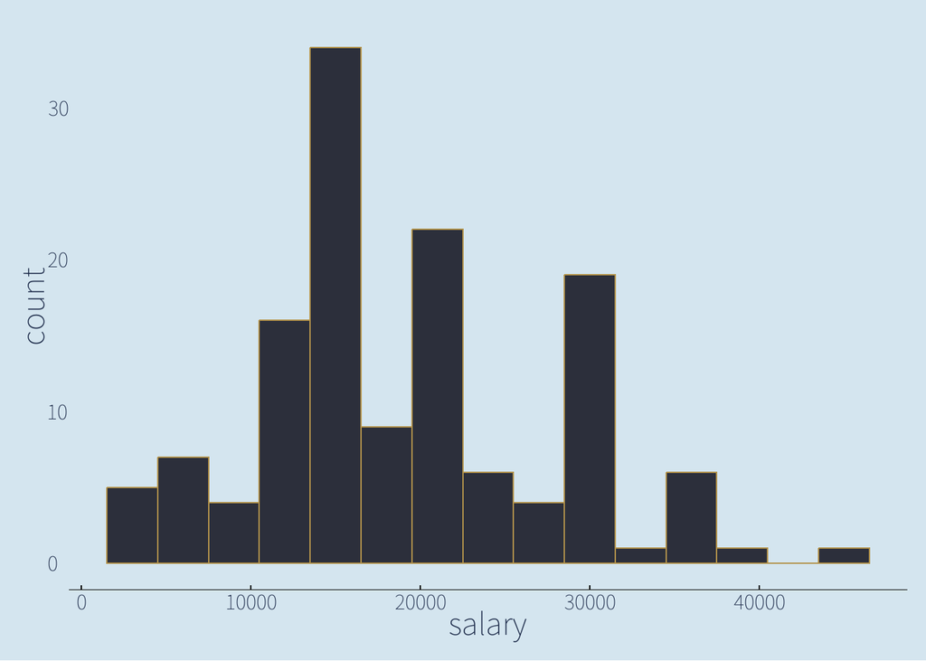

```r
df_28 %>%
    ggplot(aes(x = salary))+
    geom_histogram(binwidth = 3000,
                   fill = palette[12],
                   color = palette[7])+
    theme_chen()
```

# 32 绘制薪资水平密度曲线

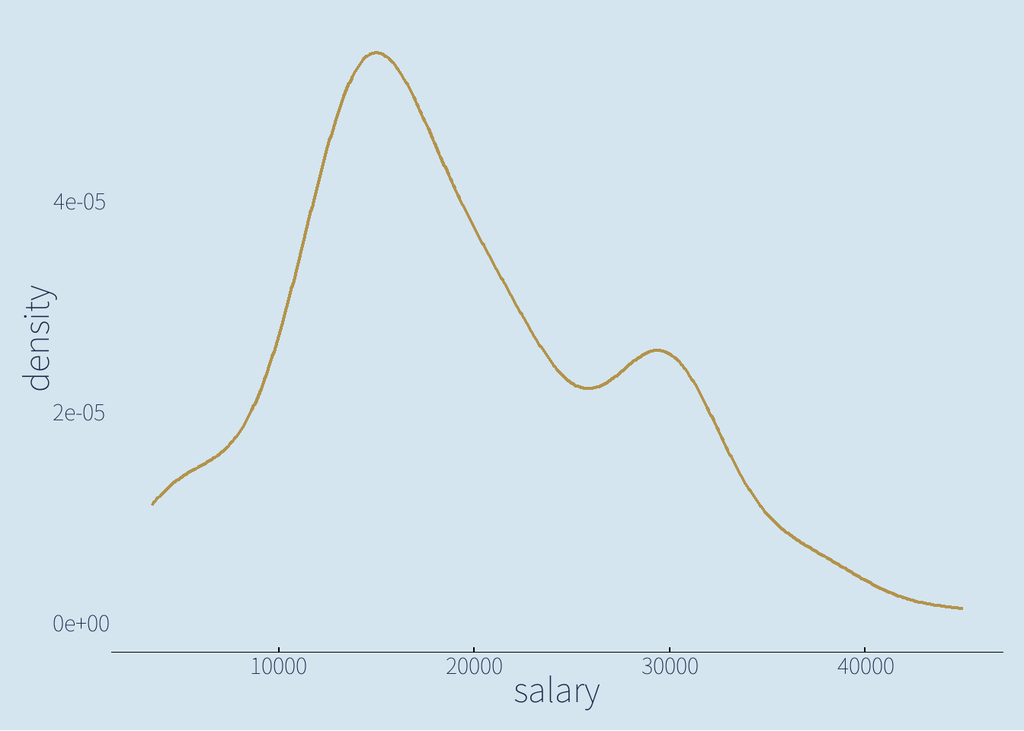

```r
showtext::showtext_auto()

df_28 %>%
    ggplot(aes(x = salary))+
    geom_density(color = palette[7],
                 linewidth = 0.8)+
    theme_chen()
```

- 按等级分下，试下效果

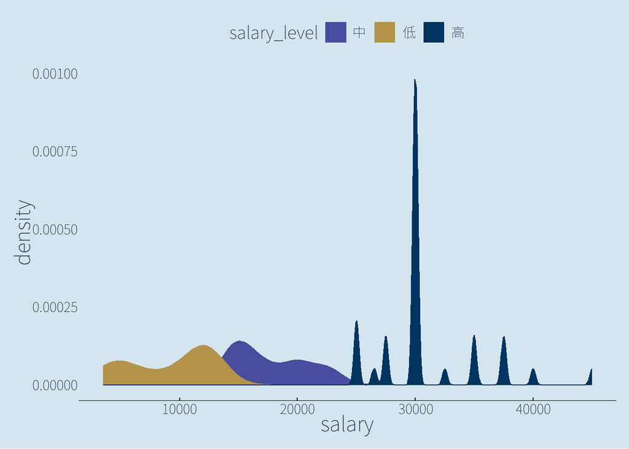

```r
df_28 %>%
    ggplot(aes(x = salary,
               group = salary_level))+
    geom_density(aes(color = salary_level,
                     fill = salary_level))+
    scale_fill_manual(values = palette[c(6,7,9)])+
    scale_color_manual(values = palette[c(6,7,9)])+
    theme_chen()
```

# 33 删除最后一列categories

前面文件的命名中，使用了salary_Level, 非categories.

删除列等于不选择该列。 属于列选择范畴，使用dplyr::select()函数。

dplyr::select()函数选择列的方式很多，本文不展开。

## 33.1 方法1：选择列位置，列数最大的一列。前加负号，及表示不选择

```r
 df_28 %>%
    select(-ncol(.)) %>%
    head(4)
```

```
## # A tibble: 4 × 5
##   createTime          education low   high  salary
##   <dttm>              <chr>     <chr> <chr>  <dbl>
## 1 2020-03-16 11:30:18 本科      20k   35k    27500
## 2 2020-03-16 10:58:47 本科      20k   40k    30000
## 3 2020-03-16 10:46:39 不限      20k   35k    27500
## 4 2020-03-16 10:45:44 本科      13k   20k    16500
```

## 33.2 方法2：选择列名

```r
 df_28 %>%
    select(-"salary_level") %>%
    head(4)
```

```
## # A tibble: 4 × 5
##   createTime          education low   high  salary
##   <dttm>              <chr>     <chr> <chr>  <dbl>
## 1 2020-03-16 11:30:18 本科      20k   35k    27500
## 2 2020-03-16 10:58:47 本科      20k   40k    30000
## 3 2020-03-16 10:46:39 不限      20k   35k    27500
## 4 2020-03-16 10:45:44 本科      13k   20k    16500
```

## 33.3 方法3：选择特征，比如包含，以什么开头等等…

```r
df_28 %>%
    select(!contains("_")) %>%  #选择列名不包含“_”的列。
head(4)
```

```
## # A tibble: 4 × 5
##   createTime          education low   high  salary
##   <dttm>              <chr>     <chr> <chr>  <dbl>
## 1 2020-03-16 11:30:18 本科      20k   35k    27500
## 2 2020-03-16 10:58:47 本科      20k   40k    30000
## 3 2020-03-16 10:46:39 不限      20k   35k    27500
## 4 2020-03-16 10:45:44 本科      13k   20k    16500
```

# 34 将df的第一列与第二列合并为新的一列

使用tidyr::untie()函数

```r
# remove 参数为FALSE
df %>%
    unite("new_col",
          1:2,
          sep = " ",
          remove = FALSE) %>%
    head(2)
```

```
##                    new_col          createTime education  salary
## 1 2020-03-16 11:30:18 本科 2020-03-16 11:30:18      本科 20k-35k
## 2 2020-03-16 10:58:48 本科 2020-03-16 10:58:47      本科 20k-40k
```

```r
# remove 参数为TRUE
df %>%
    unite("new_col",
          1:2,
          sep = " ",
          remove = TRUE) %>%
    tail(2)
```

```
##                      new_col  salary
## 134 2020-03-16 10:46:31 本科 15k-23k
## 135 2020-03-16 11:19:38 本科 20k-40k
```

# 35 将education列与salary列合并为新的一列

方法与上题类似，上题指定了列位置，本题指定列名。

```r
df %>%
    unite("new_col",
          c("education",
            "salary"),
          sep = " ",
          remove = TRUE) %>%
    head()
```

```
##            createTime      new_col
## 1 2020-03-16 11:30:18 本科 20k-35k
## 2 2020-03-16 10:58:47 本科 20k-40k
## 3 2020-03-16 10:46:39 不限 20k-35k
## 4 2020-03-16 10:45:44 本科 13k-20k
## 5 2020-03-16 10:20:41 本科 10k-20k
## 6 2020-03-16 10:33:47 本科 10k-18k
```

# 36 计算salary最大值与最小值之差

```r
range_salary <- max(df_28$salary) - min(df_28$salary)
```

38.将第一行与最后一行拼接

这属于行操作方面的内容，可以使用dplyr::slice()或filter()函数。当然，也可以使用base R 中的数据操作函数。

## 36.1 方法1：使用base R 函数处理

```r
rbind(df_28[1,],
      df_28[nrow(df_28),])
```

```
## # A tibble: 2 × 6
##   createTime          education low   high  salary salary_level
##   <dttm>              <chr>     <chr> <chr>  <dbl> <chr>
## 1 2020-03-16 11:30:18 本科      20k   35k    27500 高
## 2 2020-03-16 11:19:38 本科      20k   40k    30000 高
```

```r
df_28 %>%
    filter(row_number()==1|row_number()==n())
```

```
## # A tibble: 2 × 6
##   createTime          education low   high  salary salary_level
##   <dttm>              <chr>     <chr> <chr>  <dbl> <chr>
## 1 2020-03-16 11:30:18 本科      20k   35k    27500 高
## 2 2020-03-16 11:19:38 本科      20k   40k    30000 高
```

## 36.3 方法3：使用dplyr::slice()函数处理

```r
df_28 %>%
    slice(n()) %>%
    bind_rows(df_28[1,])
```

```
## # A tibble: 2 × 6
##   createTime          education low   high  salary salary_level
##   <dttm>              <chr>     <chr> <chr>  <dbl> <chr>
## 1 2020-03-16 11:19:38 本科      20k   40k    30000 高
## 2 2020-03-16 11:30:18 本科      20k   35k    27500 高
```

## 36.4 方法4：使用dplyr::slice()函数直接处理

直接选择对应的行，一步搞定。

```r
# 这个是最直接了当的
df_28 %>%
    slice(1,n())
```

```
## # A tibble: 2 × 6
##   createTime          education low   high  salary salary_level
##   <dttm>              <chr>     <chr> <chr>  <dbl> <chr>
## 1 2020-03-16 11:30:18 本科      20k   35k    27500 高
## 2 2020-03-16 11:19:38 本科      20k   40k    30000 高
```

# 37 将第8行数据添加至末尾

本题与上题类似。可以理解为调整数据框行的位置。

另外，前面有做过提取行的练习。

## 37.1 方法1：通过选择行的方法调整行顺序，使得第8行排在最后一行。

```r
  df_28[c(1:7,
          9:nrow(df_23_3),
          8),] %>%
tail() # 查看效果
```

```
## # A tibble: 6 × 6
##   createTime          education low   high  salary salary_level
##   <dttm>              <chr>     <chr> <chr>  <dbl> <chr>
## 1 2020-03-16 11:36:07 本科      10k   18k    14000 中
## 2 2020-03-16 09:54:47 硕士      25k   50k    37500 高
## 3 2020-03-16 10:48:32 本科      20k   40k    30000 高
## 4 2020-03-16 10:46:30 本科      15k   23k    19000 中
## 5 2020-03-16 11:19:38 本科      20k   40k    30000 高
## 6 2020-03-16 09:49:11 本科      10k   15k    12500 低
```

## 37.2 方法2：数据表与第八行数据拼接，或者说第8行数据拼接至数据表尾行，然后删除第8行。

```r
df_28 %>%
    bind_rows(.,
              df_28[8,]) %>%
    slice(-8) %>%
    tail(4) #查看效果
```

```
## # A tibble: 4 × 6
##   createTime          education low   high  salary salary_level
##   <dttm>              <chr>     <chr> <chr>  <dbl> <chr>
## 1 2020-03-16 10:48:32 本科      20k   40k    30000 高
## 2 2020-03-16 10:46:30 本科      15k   23k    19000 中
## 3 2020-03-16 11:19:38 本科      20k   40k    30000 高
## 4 2020-03-16 09:49:11 本科      10k   15k    12500 低
```

# 38 查看每列的数据类型

```r
str(df_28)
```

```
## tibble [135 × 6] (S3: tbl_df/tbl/data.frame)
##  $ createTime  : POSIXct[1:135], format: "2020-03-16 11:30:18" "2020-03-16 10:58:47" ...
##  $ education   : chr [1:135] "本科" "本科" "不限" "本科" ...
##  $ low         : chr [1:135] "20k" "20k" "20k" "13k" ...
##  $ high        : chr [1:135] "35k" "40k" "35k" "20k" ...
##  $ salary      : num [1:135] 27500 30000 27500 16500 15000 14000 23000 12500 7000 16000 ...
##  $ salary_level: chr [1:135] "高" "高" "高" "中" ...
```

# 39 将createTime列设置为索引

原始数据中，存在重复内容，重复内容不适宜作为索引，本题不能正常运行。

```r
# 这个其实就是将第一列变成行名来着
#顺便练习一下几个相关函数

has_rownames(df_28) # 检查是否有行名

df_28 <-
    remove_rownames(df_28) # 把行名干掉

# 列名变行名，column_to_rownames()
# 不知道其他人是怎样实现的，我这里报错，说是行名不能有重复的
# 然后我就用distinct()函数在135个createTime数据里找，确实发现很多重复的。这里设置不运行代码直接往下走。

df_28 %>%

    column_to_rownames("createTime")
```

# 40 生成一个和df长度相同的随机数dataframe

可以使用data.frame()和tibble()实现，本题使用tibble()实现。

```r
df42 <- tibble(random_num = runif(nrow(df_28),
                                     100,
                                     1000))

df42
```

```
## # A tibble: 135 × 1
##    random_num
##         <dbl>
##  1       209.
##  2       103.
##  3       747.
##  4       184.
##  5       167.
##  6       327.
##  7       590.
##  8       875.
##  9       199.
## 10       937.
## # ℹ 125 more rows
```

# 41 将上一题生成的dataframe与df合并

行数相同，列数不相同，优先使用列合并。可以使用base R 中的cbind()或dplyr::bind_cols()函数

## 41.1 方法1：cbind()函数

```r
df_43 <- cbind(df_28,df42)
head(df_43 )
```

```
##            createTime education low high salary salary_level random_num
## 1 2020-03-16 11:30:18      本科 20k  35k  27500           高   209.1250
## 2 2020-03-16 10:58:47      本科 20k  40k  30000           高   102.8292
## 3 2020-03-16 10:46:39      不限 20k  35k  27500           高   747.3584
## 4 2020-03-16 10:45:44      本科 13k  20k  16500           中   183.7806
## 5 2020-03-16 10:20:41      本科 10k  20k  15000           中   166.5421
## 6 2020-03-16 10:33:47      本科 10k  18k  14000           中   327.3084
```

## 41.2 方法2：bind_cols()函数

```r
df_43 <- bind_cols(df_28,df42)
head(df_43)
```

```
## # A tibble: 6 × 7
##   createTime          education low   high  salary salary_level random_num
##   <dttm>              <chr>     <chr> <chr>  <dbl> <chr>             <dbl>
## 1 2020-03-16 11:30:18 本科      20k   35k    27500 高                 209.
## 2 2020-03-16 10:58:47 本科      20k   40k    30000 高                 103.
## 3 2020-03-16 10:46:39 不限      20k   35k    27500 高                 747.
## 4 2020-03-16 10:45:44 本科      13k   20k    16500 中                 184.
## 5 2020-03-16 10:20:41 本科      10k   20k    15000 中                 167.
## 6 2020-03-16 10:33:47 本科      10k   18k    14000 中                 327.
```

# 42 生成新的一列new为salary列减去之前生成随机数列

在已有数据表中生成列，可以使用dplyr::mutate()函数 当然也可以直接生成数据向量，然后赋值给数据表的新增一列。

```r
df_44 <- df_43 %>%
    mutate(new = salary - random_num)
head(df_44)
```

```
## # A tibble: 6 × 8
##   createTime          education low   high  salary salary_level random_num
##   <dttm>              <chr>     <chr> <chr>  <dbl> <chr>             <dbl>
## 1 2020-03-16 11:30:18 本科      20k   35k    27500 高                 209.
## 2 2020-03-16 10:58:47 本科      20k   40k    30000 高                 103.
## 3 2020-03-16 10:46:39 不限      20k   35k    27500 高                 747.
## 4 2020-03-16 10:45:44 本科      13k   20k    16500 中                 184.
## 5 2020-03-16 10:20:41 本科      10k   20k    15000 中                 167.
## 6 2020-03-16 10:33:47 本科      10k   18k    14000 中                 327.
## # ℹ 1 more variable: new <dbl>
```

# 43 检查数据中是否含有任何缺失值

本题使用across()函数，配合everything()执行操作。

```r
df_44 %>%
   summarise(across(everything(),
                    ~sum(is.na(.x))))
```

```
## # A tibble: 1 × 8
##   createTime education   low  high salary salary_level random_num   new
##        <int>     <int> <int> <int>  <int>        <int>      <int> <int>
## 1          0         0     0     0      0            0          0     0
```

# 44 将salary列类型转换为浮点数

```r
df_44$salary <- as.double(df_44$salary )
```

# 45 计算salary大于10000的次数

```r
df_44 %>%
    filter(salary > 10000) %>%
    count()
```

```
## # A tibble: 1 × 1
##       n
##   <int>
## 1   119
```

# 46 查看每种学历出现的次数

```r
df_44 %>%
    count(education)
```

```
## # A tibble: 4 × 2
##   education     n
##   <chr>     <int>
## 1 不限          5
## 2 大专          4
## 3 本科        119
## 4 硕士          7
```

# 47 查看education列共有几种学历

```r
df_44 %>%
    count(education) %>%
    count()
```

```
## # A tibble: 1 × 1
##       n
##   <int>
## 1     4
```

# 48 提取salary与new列的和大于60000的最后3行

```r
 df_44 %>%
    filter(salary + new > 60000) %>%
    tail(3)
```

```
## # A tibble: 3 × 8
##   createTime          education low   high  salary salary_level random_num
##   <dttm>              <chr>     <chr> <chr>  <dbl> <chr>             <dbl>
## 1 2020-03-16 10:41:20 本科      30k   40k    35000 高                 330.
## 2 2020-03-16 11:01:39 本科      30k   45k    37500 高                 393.
## 3 2020-03-16 09:54:47 硕士      25k   50k    37500 高                 594.
## # ℹ 1 more variable: new <dbl>
```

# 49 使用绝对路径读取本地Excel数据

不同的包，读过来的数据是不一样的。格式都不一样，一个是dataframe,一个是tibble,后面对于NA 值的检查等各项操作也不一样。

## 49.1 方法1：使用xlsx包函数

```r
data <- xlsx::read.xlsx2("./data/600000.SH.xls",
                         sheetName = "600000.SH",
                         header = T,
                         na.rm =FALSE)
str(data)
```

```
## 'data.frame':    329 obs. of  19 variables:
##  $ 代码           : chr  "600000.SH" "600000.SH" "600000.SH" "600000.SH" ...
##  $ 简称           : chr  "浦发银行" "浦发银行" "浦发银行" "浦发银行" ...
##  $ 日期           : chr  "42373" "42374" "42375" "42376" ...
##  $ 前收盘价.元.   : chr  "16.1356" "15.7205" "15.8618" "15.9855" ...
##  $ 开盘价.元.     : chr  "16.1444" "15.4644" "15.8088" "15.7205" ...
##  $ 最高价.元.     : chr  "16.1444" "15.9501" "16.0208" "15.8088" ...
##  $ 最低价.元.     : chr  "15.4997" "15.3672" "15.6234" "15.3672" ...
##  $ 收盘价.元.     : chr  "15.7205" "15.8618" "15.9855" "15.4644" ...
##  $ 成交量.股.     : chr  "42240610" "58054793" "46772653" "11350479" ...
##  $ 成交金额.元.   : chr  "754425783" "1034181474" "838667398" "199502702" ...
##  $ 涨跌.元.       : chr  "-0.4151" "0.1413" "0.1236" "-0.5211" ...
##  $ 涨跌幅...      : chr  "-2.5725" "0.8989" "0.7795" "-3.2597" ...
##  $ 均价.元.       : chr  "17.8602" "17.8139" "17.9307" "17.5766" ...
##  $ 换手率...      : chr  "0.2264" "0.3112" "0.2507" "0.0608" ...
##  $ A股流通市值.元.: chr  "332031791187" "3.350163466134E11" "3.376278326115E11" "3.2662228447665E11" ...
##  $ 总市值.元.     : chr  "332031791187" "3.350163466134E11" "3.376278326115E11" "3.2662228447665E11" ...
##  $ A股流通股本.股.: chr  "18653471415" "18653471415" "18653471415" "18653471415" ...
##  $ 市盈率         : chr  "6.5614" "6.6204" "6.672" "6.4545" ...
##  $ na.rm          : logi  FALSE FALSE FALSE FALSE FALSE FALSE ...
```

## 49.2 方法2：使用readxl包包函数

```r
data_2 <- readxl::read_xls("./data/600000.SH.xls",
                           sheet = "600000.SH",
                           col_names = TRUE)

str(data_2)
```

```
## tibble [329 × 18] (S3: tbl_df/tbl/data.frame)
##  $ 代码           : chr [1:329] "600000.SH" "600000.SH" "600000.SH" "600000.SH" ...
##  $ 简称           : chr [1:329] "浦发银行" "浦发银行" "浦发银行" "浦发银行" ...
##  $ 日期           : POSIXct[1:329], format: "2016-01-04" "2016-01-05" ...
##  $ 前收盘价(元)   : num [1:329] 16.1 15.7 15.9 16 15.5 ...
##  $ 开盘价(元)     : num [1:329] 16.1 15.5 15.8 15.7 15.7 ...
##  $ 最高价(元)     : num [1:329] 16.1 16 16 15.8 15.8 ...
##  $ 最低价(元)     : num [1:329] 15.5 15.4 15.6 15.4 14.9 ...
##  $ 收盘价(元)     : num [1:329] 15.7 15.9 16 15.5 15.4 ...
##  $ 成交量(股)     : chr [1:329] "42240610" "58054793" "46772653" "11350479" ...
##  $ 成交金额(元)   : chr [1:329] "754425783" "1034181474" "838667398" "199502702" ...
##  $ 涨跌(元)       : num [1:329] -0.4151 0.1413 0.1236 -0.5211 -0.0177 ...
##  $ 涨跌幅(%)      : num [1:329] -2.572 0.899 0.779 -3.26 -0.114 ...
##  $ 均价(元)       : chr [1:329] "17.860199999999999" "17.8139" "17.930700000000002" "17.576599999999999" ...
##  $ 换手率(%)      : chr [1:329] "0.22639999999999999" "0.31119999999999998" "0.25069999999999998" "0.0608" ...
##  $ A股流通市值(元): num [1:329] 3.32e+11 3.35e+11 3.38e+11 3.27e+11 3.26e+11 ...
##  $ 总市值(元)     : num [1:329] 3.32e+11 3.35e+11 3.38e+11 3.27e+11 3.26e+11 ...
##  $ A股流通股本(股): num [1:329] 1.87e+10 1.87e+10 1.87e+10 1.87e+10 1.87e+10 ...
##  $ 市盈率         : num [1:329] 6.56 6.62 6.67 6.45 6.45 ...
```

# 50 查看数据前三行

```r
# data 和data_2两组数据首尾行数实录。
data %>%
    head(3)
```

```
##        代码     简称  日期 前收盘价.元. 开盘价.元. 最高价.元. 最低价.元.
## 1 600000.SH 浦发银行 42373      16.1356    16.1444    16.1444    15.4997
## 2 600000.SH 浦发银行 42374      15.7205    15.4644    15.9501    15.3672
## 3 600000.SH 浦发银行 42375      15.8618    15.8088    16.0208    15.6234
##   收盘价.元. 成交量.股. 成交金额.元. 涨跌.元. 涨跌幅... 均价.元. 换手率...
## 1    15.7205   42240610    754425783  -0.4151   -2.5725  17.8602    0.2264
## 2    15.8618   58054793   1034181474   0.1413    0.8989  17.8139    0.3112
## 3    15.9855   46772653    838667398   0.1236    0.7795  17.9307    0.2507
##     A股流通市值.元.        总市值.元. A股流通股本.股. 市盈率 na.rm
## 1      332031791187      332031791187     18653471415 6.5614 FALSE
## 2 3.350163466134E11 3.350163466134E11     18653471415 6.6204 FALSE
## 3 3.376278326115E11 3.376278326115E11     18653471415  6.672 FALSE
```

```r
data %>%
    tail(3)
```

```
##                   代码     简称  日期 前收盘价.元. 开盘价.元. 最高价.元.
## 327          600000.SH 浦发银行 42864        14.86      14.69      14.84
## 328
## 329 数据来源：Wind资讯
##     最低价.元. 收盘价.元. 成交量.股. 成交金额.元. 涨跌.元. 涨跌幅... 均价.元.
## 327      14.66      14.76   19225492    283864640     -0.1   -0.6729   14.765
## 328
## 329
##     换手率...    A股流通市值.元.         总市值.元. A股流通股本.股. 市盈率
## 327    0.0889 3.1908581164872E11 3.1908581164872E11     21618279922 6.0093
## 328
## 329
##     na.rm
## 327 FALSE
## 328 FALSE
## 329 FALSE
```

```r
data_2 %>%
    head(3)
```

```
## # A tibble: 3 × 18
##   代码      简称    日期                `前收盘价(元)` `开盘价(元)` `最高价(元)`
##   <chr>     <chr>   <dttm>                       <dbl>        <dbl>        <dbl>
## 1 600000.SH 浦发银… 2016-01-04 00:00:00           16.1         16.1         16.1
## 2 600000.SH 浦发银… 2016-01-05 00:00:00           15.7         15.5         16.0
## 3 600000.SH 浦发银… 2016-01-06 00:00:00           15.9         15.8         16.0
## # ℹ 12 more variables: `最低价(元)` <dbl>, `收盘价(元)` <dbl>,
## #   `成交量(股)` <chr>, `成交金额(元)` <chr>, `涨跌(元)` <dbl>,
## #   `涨跌幅(%)` <dbl>, `均价(元)` <chr>, `换手率(%)` <chr>,
## #   `A股流通市值(元)` <dbl>, `总市值(元)` <dbl>, `A股流通股本(股)` <dbl>,
## #   市盈率 <dbl>
```

```r
data_2%>%
    tail(3)
```

```
## # A tibble: 3 × 18
##   代码        简称  日期                `前收盘价(元)` `开盘价(元)` `最高价(元)`
##   <chr>       <chr> <dttm>                       <dbl>        <dbl>        <dbl>
## 1 600000.SH   浦发… 2017-05-09 00:00:00           14.9         14.7         14.8
## 2 <NA>        <NA>  NA                            NA           NA           NA
## 3 数据来源：… <NA>  NA                            NA           NA           NA
## # ℹ 12 more variables: `最低价(元)` <dbl>, `收盘价(元)` <dbl>,
## #   `成交量(股)` <chr>, `成交金额(元)` <chr>, `涨跌(元)` <dbl>,
## #   `涨跌幅(%)` <dbl>, `均价(元)` <chr>, `换手率(%)` <chr>,
## #   `A股流通市值(元)` <dbl>, `总市值(元)` <dbl>, `A股流通股本(股)` <dbl>,
## #   市盈率 <dbl>
```

```r
# data 和data_2两组数据首尾行数实录。
```

# 51 查看每列数据缺失值情况

## 51.1 对于data数据，检测不到NA值.

### 51.1.1 方法1:colSums()函数

```r
is.na(data) %>%
    colSums()
```

```
##            代码            简称            日期    前收盘价.元.      开盘价.元.
##               0               0               0               0               0
##      最高价.元.      最低价.元.      收盘价.元.      成交量.股.    成交金额.元.
##               0               0               0               0               0
##        涨跌.元.       涨跌幅...        均价.元.       换手率... A股流通市值.元.
##               0               0               0               0               0
##      总市值.元. A股流通股本.股.          市盈率           na.rm
##               0               0               0               0
```

### 51.1.2 方法2：用across()函数处理

```r
data %>%
   summarise(across(everything(),
                    ~sum(is.na(.x))))
```

```
##   代码 简称 日期 前收盘价.元. 开盘价.元. 最高价.元. 最低价.元. 收盘价.元.
## 1    0    0    0            0          0          0          0          0
##   成交量.股. 成交金额.元. 涨跌.元. 涨跌幅... 均价.元. 换手率... A股流通市值.元.
## 1          0            0        0         0        0         0               0
##   总市值.元. A股流通股本.股. 市盈率 na.rm
## 1          0               0      0     0
```

## 51.2 对于data_2 数据，tibble 类型的数据，可以检测到NA值。

### 51.2.1 方法1:colSums()函数

```r
 is.na(data_2) %>%
    colSums()
```

```
##            代码            简称            日期    前收盘价(元)      开盘价(元)
##               1               2               2               2               2
##      最高价(元)      最低价(元)      收盘价(元)      成交量(股)    成交金额(元)
##               2               2               2               2               2
##        涨跌(元)       涨跌幅(%)        均价(元)       换手率(%) A股流通市值(元)
##               2               2               2               2               2
##      总市值(元) A股流通股本(股)          市盈率
##               2               2               2
```

### 51.2.2 方法2：用across()函数处理

```r
 data_2 %>%
   summarise(across(everything(),
                    ~sum(is.na(.x))))
```

```
## # A tibble: 1 × 18
##    代码  简称  日期 `前收盘价(元)` `开盘价(元)` `最高价(元)` `最低价(元)`
##   <int> <int> <int>          <int>        <int>        <int>        <int>
## 1     1     2     2              2            2            2            2
## # ℹ 11 more variables: `收盘价(元)` <int>, `成交量(股)` <int>,
## #   `成交金额(元)` <int>, `涨跌(元)` <int>, `涨跌幅(%)` <int>,
## #   `均价(元)` <int>, `换手率(%)` <int>, `A股流通市值(元)` <int>,
## #   `总市值(元)` <int>, `A股流通股本(股)` <int>, 市盈率 <int>
```

后续各题相关数据使用data_2执行计算分析。

# 52 提取日期列含有空值的行

```r
data_2 %>%
    filter(is.na(日期))
```

```
## # A tibble: 2 × 18
##   代码        简称  日期   `前收盘价(元)` `开盘价(元)` `最高价(元)`
##   <chr>       <chr> <dttm>          <dbl>        <dbl>        <dbl>
## 1 <NA>        <NA>  NA                 NA           NA           NA
## 2 数据来源：… <NA>  NA                 NA           NA           NA
## # ℹ 12 more variables: `最低价(元)` <dbl>, `收盘价(元)` <dbl>,
## #   `成交量(股)` <chr>, `成交金额(元)` <chr>, `涨跌(元)` <dbl>,
## #   `涨跌幅(%)` <dbl>, `均价(元)` <chr>, `换手率(%)` <chr>,
## #   `A股流通市值(元)` <dbl>, `总市值(元)` <dbl>, `A股流通股本(股)` <dbl>,
## #   市盈率 <dbl>
```

# 53 输出每列缺失值具体行数

和前面题目相类似

```r
  data_2 %>%
   summarise(across(everything(),
                    ~sum(is.na(.x))))
```

```
## # A tibble: 1 × 18
##    代码  简称  日期 `前收盘价(元)` `开盘价(元)` `最高价(元)` `最低价(元)`
##   <int> <int> <int>          <int>        <int>        <int>        <int>
## 1     1     2     2              2            2            2            2
## # ℹ 11 more variables: `收盘价(元)` <int>, `成交量(股)` <int>,
## #   `成交金额(元)` <int>, `涨跌(元)` <int>, `涨跌幅(%)` <int>,
## #   `均价(元)` <int>, `换手率(%)` <int>, `A股流通市值(元)` <int>,
## #   `总市值(元)` <int>, `A股流通股本(股)` <int>, 市盈率 <int>
```

# 54 删除所有存在缺失值的行

## 54.1 方法1：drop.na()函数

```r
  data_56 <- data_2 %>%
   drop_na()

  tail(data_56) # 查看效果
```

```
## # A tibble: 6 × 18
##   代码      简称    日期                `前收盘价(元)` `开盘价(元)` `最高价(元)`
##   <chr>     <chr>   <dttm>                       <dbl>        <dbl>        <dbl>
## 1 600000.SH 浦发银… 2017-05-02 00:00:00           15.2         15.2         15.2
## 2 600000.SH 浦发银… 2017-05-03 00:00:00           15.2         15.2         15.2
## 3 600000.SH 浦发银… 2017-05-04 00:00:00           15.1         15.1         15.1
## 4 600000.SH 浦发银… 2017-05-05 00:00:00           15.0         15.0         15.0
## 5 600000.SH 浦发银… 2017-05-08 00:00:00           14.9         14.8         14.9
## 6 600000.SH 浦发银… 2017-05-09 00:00:00           14.9         14.7         14.8
## # ℹ 12 more variables: `最低价(元)` <dbl>, `收盘价(元)` <dbl>,
## #   `成交量(股)` <chr>, `成交金额(元)` <chr>, `涨跌(元)` <dbl>,
## #   `涨跌幅(%)` <dbl>, `均价(元)` <chr>, `换手率(%)` <chr>,
## #   `A股流通市值(元)` <dbl>, `总市值(元)` <dbl>, `A股流通股本(股)` <dbl>,
## #   市盈率 <dbl>
```

## 54.2 方法2：na.omit()函数

```r
na.omit(data_2) %>%
      tail()  # 查看效果
```

```
## # A tibble: 6 × 18
##   代码      简称    日期                `前收盘价(元)` `开盘价(元)` `最高价(元)`
##   <chr>     <chr>   <dttm>                       <dbl>        <dbl>        <dbl>
## 1 600000.SH 浦发银… 2017-05-02 00:00:00           15.2         15.2         15.2
## 2 600000.SH 浦发银… 2017-05-03 00:00:00           15.2         15.2         15.2
## 3 600000.SH 浦发银… 2017-05-04 00:00:00           15.1         15.1         15.1
## 4 600000.SH 浦发银… 2017-05-05 00:00:00           15.0         15.0         15.0
## 5 600000.SH 浦发银… 2017-05-08 00:00:00           14.9         14.8         14.9
## 6 600000.SH 浦发银… 2017-05-09 00:00:00           14.9         14.7         14.8
## # ℹ 12 more variables: `最低价(元)` <dbl>, `收盘价(元)` <dbl>,
## #   `成交量(股)` <chr>, `成交金额(元)` <chr>, `涨跌(元)` <dbl>,
## #   `涨跌幅(%)` <dbl>, `均价(元)` <chr>, `换手率(%)` <chr>,
## #   `A股流通市值(元)` <dbl>, `总市值(元)` <dbl>, `A股流通股本(股)` <dbl>,
## #   市盈率 <dbl>
```

# 55 绘制收盘价的折线图

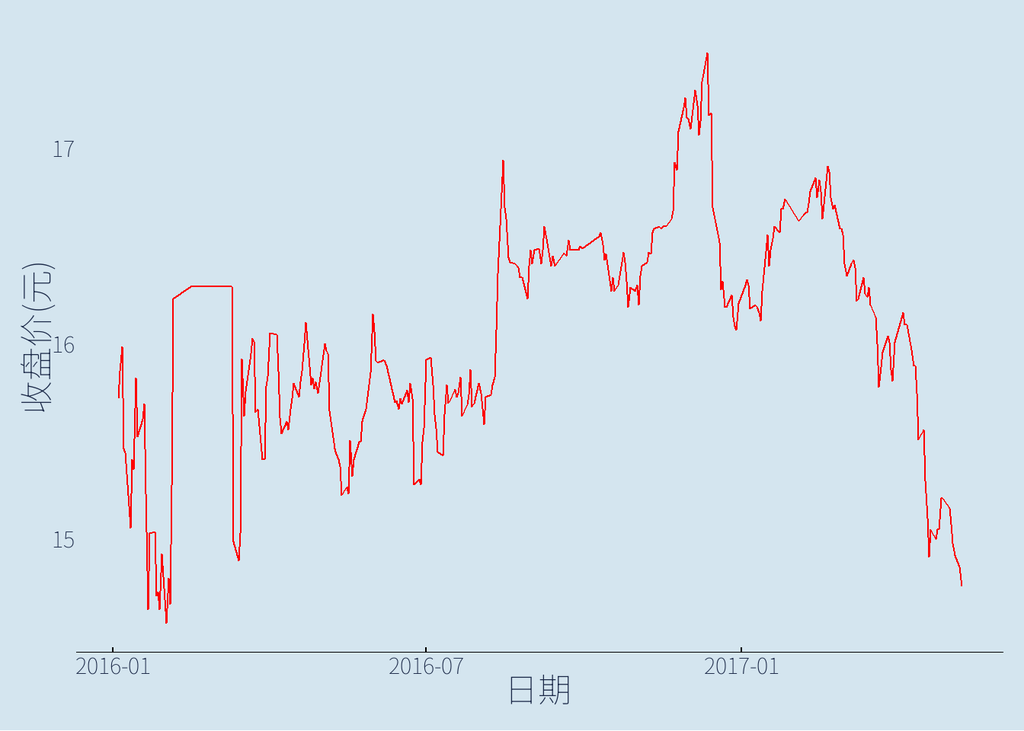

```r
data_56 %>%
    ggplot(aes(x = 日期,
               y = `收盘价(元)`))+
    # y值变量名有括号，用`` 把他包起来即可。
    geom_line(show.legend = TRUE,
              colour = "red")+
    theme_chen()
```

# 56 同时绘制开盘价与收盘价

## 56.1 方法1：使用宽数据

aes里没有足够的变量，show.legend为TRUE,也没有用。这种图没有图例，那是比较糟糕的。

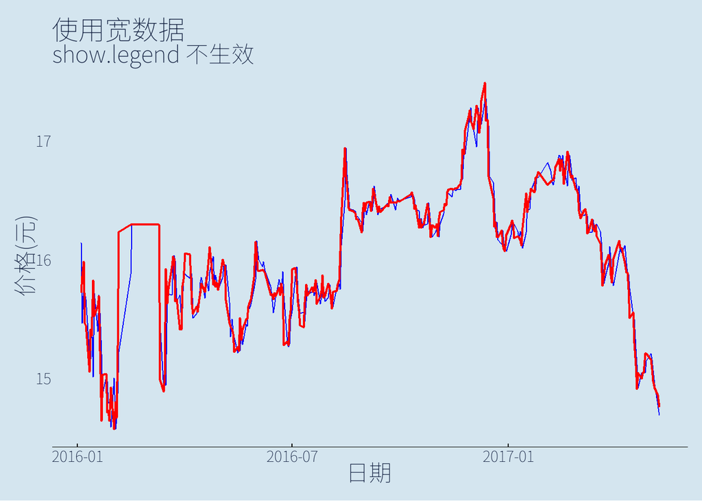

```r
data_56 %>%
    ggplot(aes(x = 日期))+

    geom_line(aes(x = 日期,
                  y = `开盘价(元)`),
              linewidth = 0.4,
              color = "blue",
              show.legend = TRUE)+

    geom_line(aes(x = 日期,
                  y = `收盘价(元)`),
              linewidth = 0.8,
              show.legend = TRUE,
              color = "red")+
    labs(y = "价格(元)",
         title = "使用宽数据",
         subtitle = "show.legend 不生效") +
    theme_chen()
```

## 56.2 方法2：使用长数据

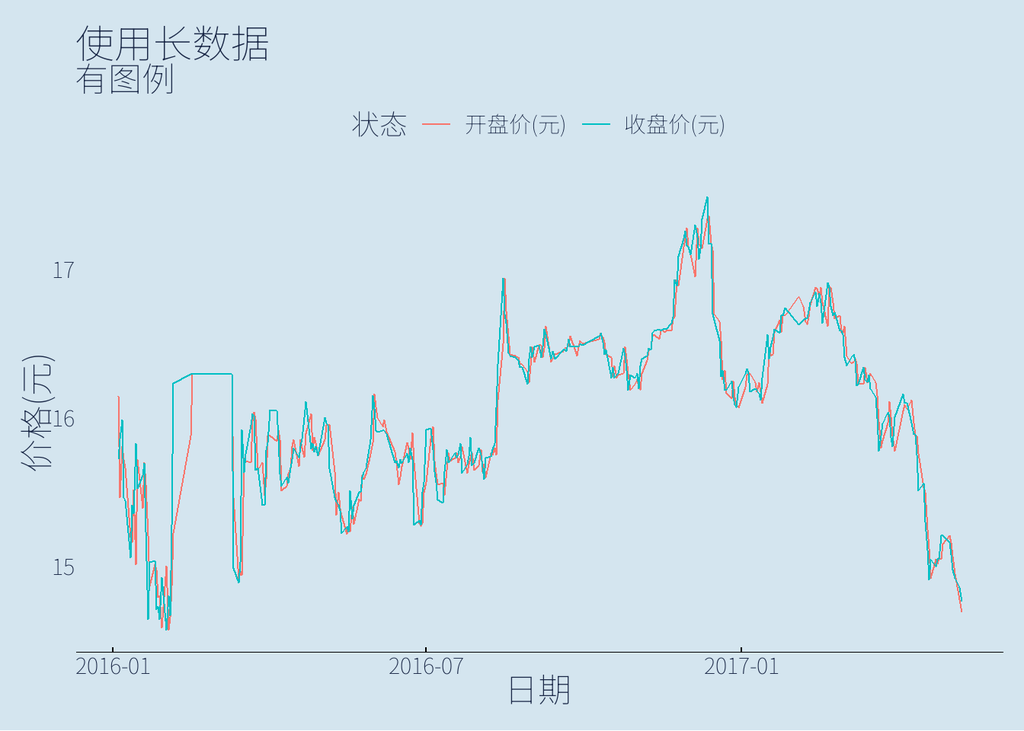

```r
data_56 %>%
    select(c(3,5,8)) %>%
    pivot_longer(2:3,names_to = "状态",values_to = "价格(元)") %>%
    ggplot(aes(x = 日期, y = `价格(元)`,group = 状态)) +
    geom_line(aes(color = 状态)) +
     theme_bw()+
      labs(title = "使用长数据",
         subtitle = "有图例")+
    theme_chen()
```

# 57 绘制涨跌幅的直方图

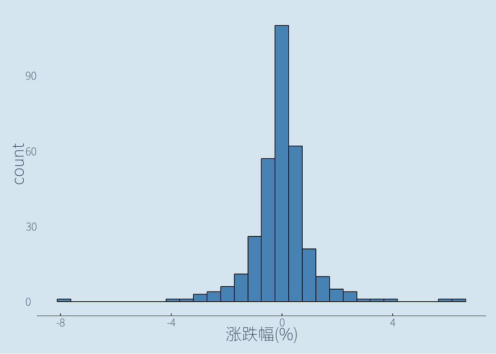

```r
data_56 %>%
    ggplot(aes(`涨跌幅(%)`)) +
    geom_histogram(fill = "steelblue",color = "black")+
    theme_chen()
```

# 58 让直方图更细致

理解题目的意图是调节bin和，柱子宽度这方面的想法

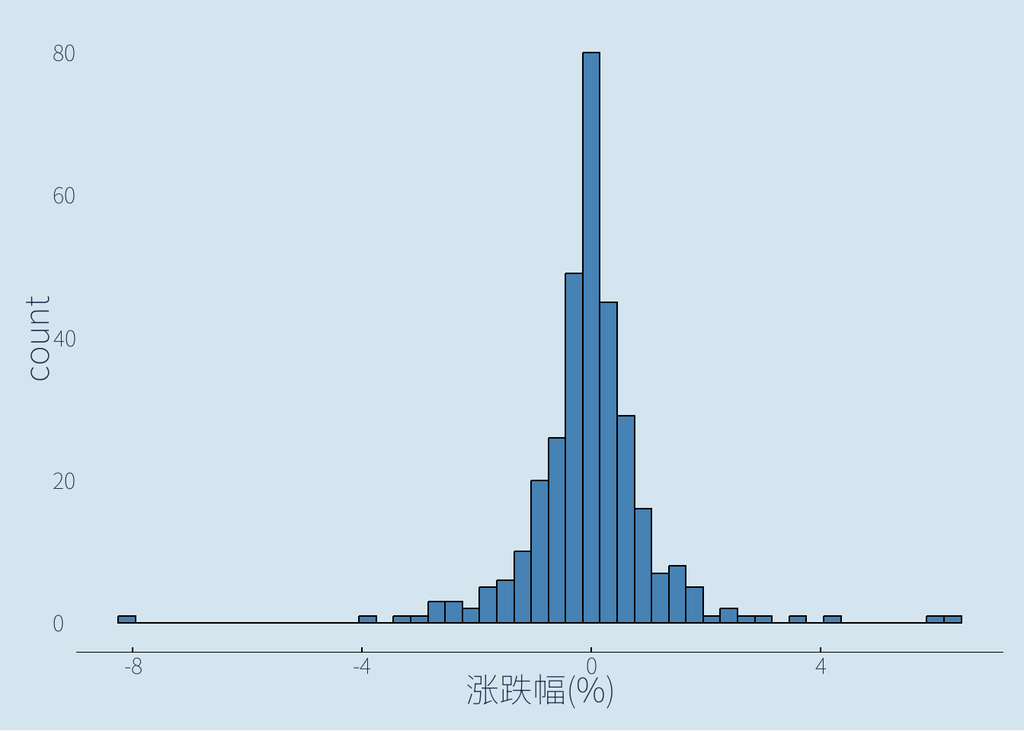

```r
data_56 %>%
    ggplot(aes(`涨跌幅(%)`)) +
    geom_histogram(binwidth = 0.3,fill = "steelblue",color = "black")+
    theme_chen()
```

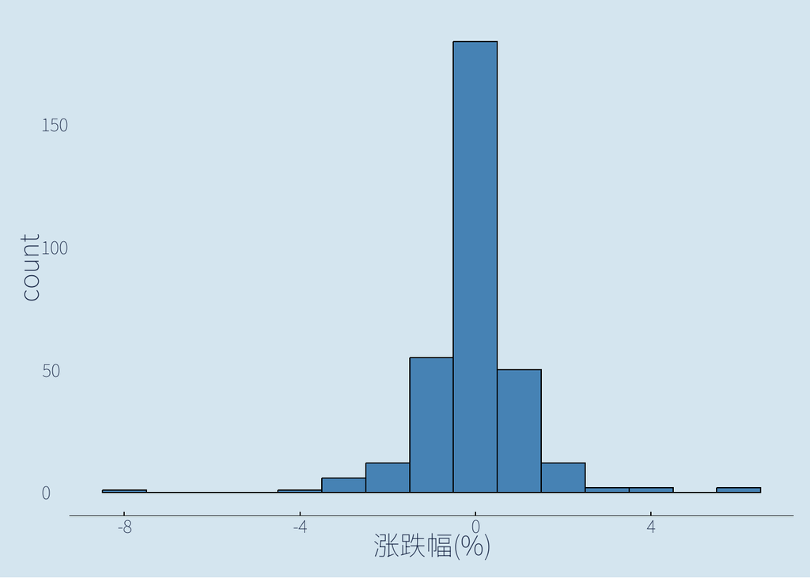

```r
data_56 %>%
    ggplot(aes(`涨跌幅(%)`)) +
    geom_histogram(binwidth = 1,fill = "steelblue",color = "black")+
    theme_chen()
```

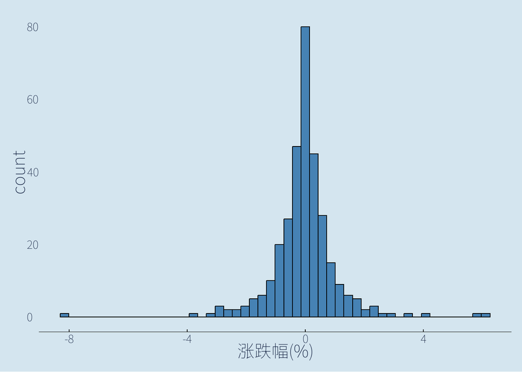

```r
data_56 %>%
    ggplot(aes(`涨跌幅(%)`)) +
    geom_histogram(bins = 50,fill = "steelblue",color = "black")+
    theme_chen()
```

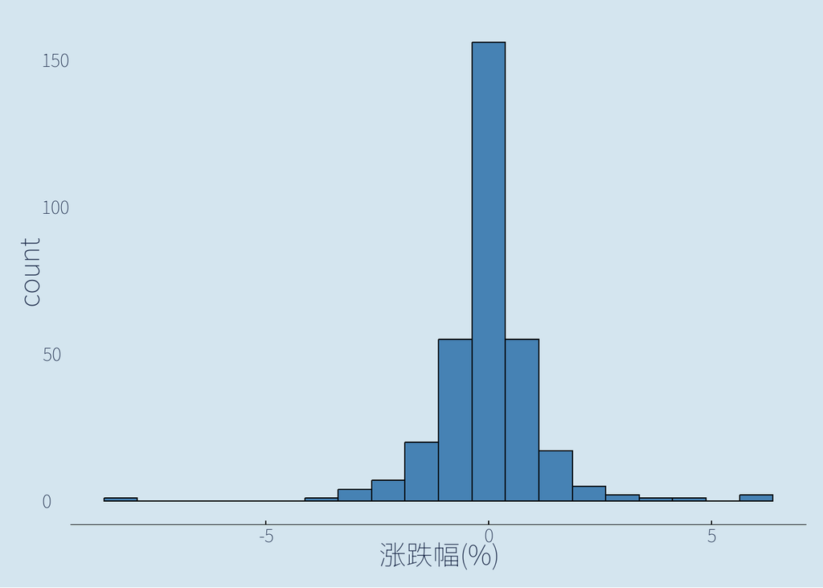

```r
data_56 %>%
    ggplot(aes(`涨跌幅(%)`)) +
    geom_histogram(bins = 20,fill = "steelblue",color = "black")+
    theme_chen()
```

# 59 以data的列名创建一个dataframe

```r
ndf <- names(data_56) %>%
    as_tibble()

ndf
```

```
## # A tibble: 18 × 1
##    value
##    <chr>
##  1 代码
##  2 简称
##  3 日期
##  4 前收盘价(元)
##  5 开盘价(元)
##  6 最高价(元)
##  7 最低价(元)
##  8 收盘价(元)
##  9 成交量(股)
## 10 成交金额(元)
## 11 涨跌(元)
## 12 涨跌幅(%)
## 13 均价(元)
## 14 换手率(%)
## 15 A股流通市值(元)
## 16 总市值(元)
## 17 A股流通股本(股)
## 18 市盈率
```

# 60 打印所有换手率不是数字的行

其实原始数据读入后，该列数据全部都不是数字型，而是字符串型；

把列强制改为数字型，然后，这个过程中，非数字型的字符变成了NA;

不是数字的行，其实就变成了是NA 的行。

```r
 data_56 %>%
    mutate(`换手率(%)` = as.numeric(`换手率(%)`)) %>%
    filter(is.na(`换手率(%)`)) %>%
    select(`换手率(%)`,
           everything()) %>%
    head(3)
```

```
## # A tibble: 3 × 18
##   `换手率(%)` 代码      简称     日期                `前收盘价(元)` `开盘价(元)`
##         <dbl> <chr>     <chr>    <dttm>                       <dbl>        <dbl>
## 1          NA 600000.SH 浦发银行 2016-02-16 00:00:00           16.3         16.3
## 2          NA 600000.SH 浦发银行 2016-02-17 00:00:00           16.3         16.3
## 3          NA 600000.SH 浦发银行 2016-02-18 00:00:00           16.3         16.3
## # ℹ 12 more variables: `最高价(元)` <dbl>, `最低价(元)` <dbl>,
## #   `收盘价(元)` <dbl>, `成交量(股)` <chr>, `成交金额(元)` <chr>,
## #   `涨跌(元)` <dbl>, `涨跌幅(%)` <dbl>, `均价(元)` <chr>,
## #   `A股流通市值(元)` <dbl>, `总市值(元)` <dbl>, `A股流通股本(股)` <dbl>,
## #   市盈率 <dbl>
```

```r
# 把换手率列前移，查看前三行
```

# 61 打印所有换手率为–的行

```r
 data_56 %>%
    filter(`换手率(%)` =="--") %>%
    select(`换手率(%)`,
           everything()) %>%
    head(3)
```

```
## # A tibble: 3 × 18
##   `换手率(%)` 代码      简称     日期                `前收盘价(元)` `开盘价(元)`
##   <chr>       <chr>     <chr>    <dttm>                       <dbl>        <dbl>
## 1 --          600000.SH 浦发银行 2016-02-16 00:00:00           16.3         16.3
## 2 --          600000.SH 浦发银行 2016-02-17 00:00:00           16.3         16.3
## 3 --          600000.SH 浦发银行 2016-02-18 00:00:00           16.3         16.3
## # ℹ 12 more variables: `最高价(元)` <dbl>, `最低价(元)` <dbl>,
## #   `收盘价(元)` <dbl>, `成交量(股)` <chr>, `成交金额(元)` <chr>,
## #   `涨跌(元)` <dbl>, `涨跌幅(%)` <dbl>, `均价(元)` <chr>,
## #   `A股流通市值(元)` <dbl>, `总市值(元)` <dbl>, `A股流通股本(股)` <dbl>,
## #   市盈率 <dbl>
```

```r
# 与上题类似。
```

# 62 重置data的行号

```r
set.seed(1234)

data_56 %>%
    rowid_to_column() %>%
    column_to_rownames("rowid") %>%
    head(3)
```

```
##        代码     简称       日期 前收盘价(元) 开盘价(元) 最高价(元) 最低价(元)
## 1 600000.SH 浦发银行 2016-01-04      16.1356    16.1444    16.1444    15.4997
## 2 600000.SH 浦发银行 2016-01-05      15.7205    15.4644    15.9501    15.3672
## 3 600000.SH 浦发银行 2016-01-06      15.8618    15.8088    16.0208    15.6234
##   收盘价(元) 成交量(股) 成交金额(元) 涨跌(元) 涨跌幅(%)           均价(元)
## 1    15.7205   42240610    754425783  -0.4151   -2.5725 17.860199999999999
## 2    15.8618   58054793   1034181474   0.1413    0.8989            17.8139
## 3    15.9855   46772653    838667398   0.1236    0.7795 17.930700000000002
##             换手率(%) A股流通市值(元)   总市值(元) A股流通股本(股) 市盈率
## 1 0.22639999999999999    332031791187 332031791187     18653471415 6.5614
## 2 0.31119999999999998    335016346613 335016346613     18653471415 6.6204
## 3 0.25069999999999998    337627832612 337627832612     18653471415 6.6720
```

# 63 删除所有换手率为非数字的行

```r
data_65 <- data_56 %>%
    mutate(`换手率(%)` = as.numeric(`换手率(%)`)) %>%
    drop_na(`换手率(%)`)
```

# 64 绘制换手率的密度曲线

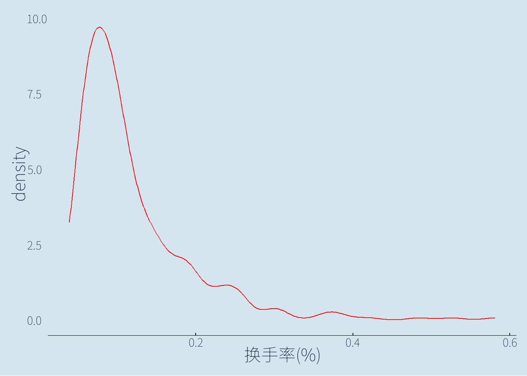

```r
data_65 %>%
    ggplot(aes(`换手率(%)`)) +
    geom_density(color = "red")+
    theme_chen()
```

# 65 计算前一天与后一天收盘价的差值

```r
data_65 %>%
mutate(gap = `收盘价(元)`- lag(n = 1,`收盘价(元)` ),
       .after = `收盘价(元)` ) %>%
    head(3)
```

```
## # A tibble: 3 × 19
##   代码      简称    日期                `前收盘价(元)` `开盘价(元)` `最高价(元)`
##   <chr>     <chr>   <dttm>                       <dbl>        <dbl>        <dbl>
## 1 600000.SH 浦发银… 2016-01-04 00:00:00           16.1         16.1         16.1
## 2 600000.SH 浦发银… 2016-01-05 00:00:00           15.7         15.5         16.0
## 3 600000.SH 浦发银… 2016-01-06 00:00:00           15.9         15.8         16.0
## # ℹ 13 more variables: `最低价(元)` <dbl>, `收盘价(元)` <dbl>, gap <dbl>,
## #   `成交量(股)` <chr>, `成交金额(元)` <chr>, `涨跌(元)` <dbl>,
## #   `涨跌幅(%)` <dbl>, `均价(元)` <chr>, `换手率(%)` <dbl>,
## #   `A股流通市值(元)` <dbl>, `总市值(元)` <dbl>, `A股流通股本(股)` <dbl>,
## #   市盈率 <dbl>
```

# 66 计算前一天与后一天收盘价变化率

```r
data_65 %>%
mutate(gap = `收盘价(元)`- lag(n = 1,`收盘价(元)`),
       ratio = (gap/`收盘价(元)`) %>%
           scales::percent(accuracy = 0.01),
       .before = `收盘价(元)` ) %>%
    head(3)
```

```
## # A tibble: 3 × 20
##   代码      简称    日期                `前收盘价(元)` `开盘价(元)` `最高价(元)`
##   <chr>     <chr>   <dttm>                       <dbl>        <dbl>        <dbl>
## 1 600000.SH 浦发银… 2016-01-04 00:00:00           16.1         16.1         16.1
## 2 600000.SH 浦发银… 2016-01-05 00:00:00           15.7         15.5         16.0
## 3 600000.SH 浦发银… 2016-01-06 00:00:00           15.9         15.8         16.0
## # ℹ 14 more variables: `最低价(元)` <dbl>, gap <dbl>, ratio <chr>,
## #   `收盘价(元)` <dbl>, `成交量(股)` <chr>, `成交金额(元)` <chr>,
## #   `涨跌(元)` <dbl>, `涨跌幅(%)` <dbl>, `均价(元)` <chr>, `换手率(%)` <dbl>,
## #   `A股流通市值(元)` <dbl>, `总市值(元)` <dbl>, `A股流通股本(股)` <dbl>,
## #   市盈率 <dbl>
```

# 67 设置日期为索引

```r
data_65 %>%
    column_to_rownames("日期") %>%
    head(3)
```

```
##                 代码     简称 前收盘价(元) 开盘价(元) 最高价(元) 最低价(元)
## 2016-01-04 600000.SH 浦发银行      16.1356    16.1444    16.1444    15.4997
## 2016-01-05 600000.SH 浦发银行      15.7205    15.4644    15.9501    15.3672
## 2016-01-06 600000.SH 浦发银行      15.8618    15.8088    16.0208    15.6234
##            收盘价(元) 成交量(股) 成交金额(元) 涨跌(元) 涨跌幅(%)
## 2016-01-04    15.7205   42240610    754425783  -0.4151   -2.5725
## 2016-01-05    15.8618   58054793   1034181474   0.1413    0.8989
## 2016-01-06    15.9855   46772653    838667398   0.1236    0.7795
##                      均价(元) 换手率(%) A股流通市值(元)   总市值(元)
## 2016-01-04 17.860199999999999    0.2264    332031791187 332031791187
## 2016-01-05            17.8139    0.3112    335016346613 335016346613
## 2016-01-06 17.930700000000002    0.2507    337627832612 337627832612
##            A股流通股本(股) 市盈率
## 2016-01-04     18653471415 6.5614
## 2016-01-05     18653471415 6.6204
## 2016-01-06     18653471415 6.6720
```

# 68 以5个数据作为一个数据滑动窗口，在这个5个数据上取均值(收盘价)

这就是股票里的5日均线或者说那种移动平均值的计算。实现的方法非常多，本题使用自编函数以及几种常用包及函数进行计算。

## 68.1 方法1：用基础包和tidyverse 相关函数做函数自己计算

```r
 ma_fun <- function(data, width){
   i  = length(data)
   if(width > i){
       return("数据不够，请增加数据")
   }
   k =width:i
   ma_value =c(rep(NA,width-1),
              map_vec(k,\(x) mean(data[(x-(width-1)):x])))
return( ma_value)
 }

data_65 %>%
    transmute(average_5 = ma_fun(`收盘价(元)`,5))
```

```
## # A tibble: 309 × 1
##    average_5
##        <dbl>
##  1      NA
##  2      NA
##  3      NA
##  4      NA
##  5      15.7
##  6      15.6
##  7      15.5
##  8      15.3
##  9      15.4
## 10      15.4
## # ℹ 299 more rows
```

## 68.2 方法2：调用相关的基础函数计算：zoo::rollmean()函数

```r
data_65 %>%
    transmute(average_5 = zoo::rollmean(`收盘价(元)`,5,
                                        align = "right",
                                        fill = NA))
```

```
## # A tibble: 309 × 1
##    average_5
##        <dbl>
##  1      NA
##  2      NA
##  3      NA
##  4      NA
##  5      15.7
##  6      15.6
##  7      15.5
##  8      15.3
##  9      15.4
## 10      15.4
## # ℹ 299 more rows
```

## 68.3 方法3：调用相关的基础函数计算：DescTools::MoveAvg()函数

```r
data_65 %>%
    transmute(average_5 = DescTools::MoveAvg(x = `收盘价(元)`,
                                             order = 5,
                                             align = "right",
                                             endrule = "NA" ))
```

```
## # A tibble: 309 × 1
##    average_5
##        <dbl>
##  1      NA
##  2      NA
##  3      NA
##  4      NA
##  5      15.7
##  6      15.6
##  7      15.5
##  8      15.3
##  9      15.4
## 10      15.4
## # ℹ 299 more rows
```

## 68.4 方法4：调用相关的基础函数计算：slider::slide_dbl()函数

```r
data_65 %>%
    transmute(average_5 = slider::slide_dbl( `收盘价(元)`,
                                         mean,
                                         .before = 4,
                                         .complete = TRUE))
```

```
## # A tibble: 309 × 1
##    average_5
##        <dbl>
##  1      NA
##  2      NA
##  3      NA
##  4      NA
##  5      15.7
##  6      15.6
##  7      15.5
##  8      15.3
##  9      15.4
## 10      15.4
## # ℹ 299 more rows
```

# 69 以5个数据作为一个数据滑动窗口，计算这五个数据总和(收盘价)

与计算均值同样的逻辑。

## 69.1 方法1：用基础包和tidyverse 相关函数做函数自己计算

```r
 ms_fun <- function(data, width){
   i  = length(data)
   if(width > i){
       return("数据不够，请增加数据")
   }
   k =width:i
   ms_value =c(rep(NA,width-1),
              map_vec(k,\(x) sum(data[(x-(width-1)):x])))
return( ms_value)
 }

data_65 %>%
    transmute(sum_5 = ms_fun(`收盘价(元)`,5))
```

```
## # A tibble: 309 × 1
##    sum_5
##    <dbl>
##  1  NA
##  2  NA
##  3  NA
##  4  NA
##  5  78.5
##  6  77.8
##  7  77.4
##  8  76.7
##  9  77.1
## 10  77.2
## # ℹ 299 more rows
```

## 69.2 方法2：调用相关的基础函数计算：zoo::rollsum函数

有很多金融和时序相关的包都有类似函数，类似roll sum,move average这类函数，见诸于zoo,xts,quantmod,TTR等包，而tidyquant有个综合函数，整合引用这些函数。这里用zoo包里的函数做一下。

```r
data_65 %>%
    transmute(sum_5 = zoo::rollsum(`收盘价(元)`,
                                   5,
                                   align = "right",
                                   fill = NA))
```

```
## # A tibble: 309 × 1
##    sum_5
##    <dbl>
##  1  NA
##  2  NA
##  3  NA
##  4  NA
##  5  78.5
##  6  77.8
##  7  77.4
##  8  76.7
##  9  77.1
## 10  77.2
## # ℹ 299 more rows
```

## 69.3 方法3：调用相关的基础函数计算：slider::slide_dbl()函数

```r
data_65 %>%
    transmute(sum_5 = slider::slide_dbl( `收盘价(元)`,
                                         sum,
                                         .before = 4,
                                         .complete = TRUE))
```

```
## # A tibble: 309 × 1
##    sum_5
##    <dbl>
##  1  NA
##  2  NA
##  3  NA
##  4  NA
##  5  78.5
##  6  77.8
##  7  77.4
##  8  76.7
##  9  77.1
## 10  77.2
## # ℹ 299 more rows
```

# 70 将收盘价5日均线、20日均线与原始数据绘制在同一个图上

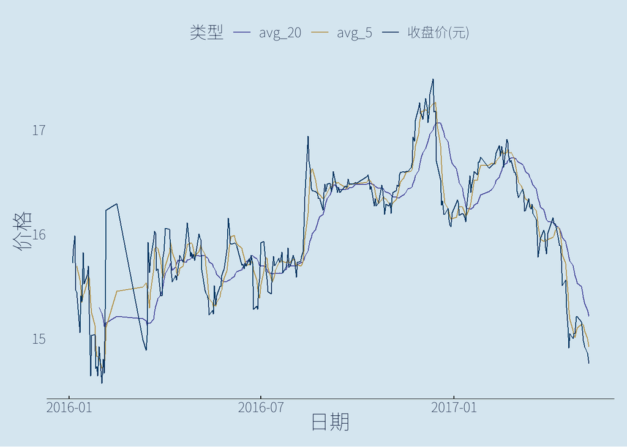

```r
data_65 %>%
    select(日期,`收盘价(元)`) %>%
    mutate(avg_5 = ma_fun(`收盘价(元)`,5),
           avg_20 = ma_fun(`收盘价(元)`,20)) %>%
    tidyr::pivot_longer(-1,
                        names_to = "类型",
                        values_to = "价格") %>%
    ggplot(aes(x = 日期,
               y = 价格,
               group = 类型))+
    geom_line(aes(color = 类型))+
     scale_color_manual(values = palette[c(6,7,9)])+
    theme_chen()
```

# 71 按周为采样规则，取一周收盘价最大值

不能机械的使用period 滑窗取最大值，因为有些假期日期是没有数据的；

也不能简单的取日期的周期，然后分组取最大值，因为有不同的年份的考虑；

可以按年-周两级分组，求最大值；

或者机械的把他们合到一起，当作是做特征工程； 最好的办法就是找到年+周的显示方法函数(欧美公司里基本都是用年-周工作逻辑来的)

## 71.1 方法1：年、周两级分组求最大值；

这个逻辑还是很清晰的：先group,再执行操作

```r
data_65 %>%
    select(日期,`收盘价(元)`) %>%
    mutate(year = year(日期),
        weeknum =  week(日期)) %>%
    group_by(year,weeknum) %>%
    slice_max(`收盘价(元)`)
```

```
## # A tibble: 74 × 4
## # Groups:   year, weeknum [69]
##    日期                `收盘价(元)`  year weeknum
##    <dttm>                     <dbl> <dbl>   <dbl>
##  1 2016-01-06 00:00:00         16.0  2016       1
##  2 2016-01-14 00:00:00         15.8  2016       2
##  3 2016-01-19 00:00:00         15.7  2016       3
##  4 2016-01-25 00:00:00         15.0  2016       4
##  5 2016-02-04 00:00:00         15.3  2016       5
##  6 2016-02-05 00:00:00         16.2  2016       6
##  7 2016-02-15 00:00:00         16.3  2016       7
##  8 2016-03-16 00:00:00         15.9  2016      11
##  9 2016-03-22 00:00:00         16.0  2016      12
## 10 2016-03-31 00:00:00         15.8  2016      13
## # ℹ 64 more rows
```

## 71.2 方法2：年-组合字段,group 对象作为参数选项放在函数里。

```r
data_65 %>%
    select(日期,`收盘价(元)`) %>%
    mutate(year_week = str_c(year(日期),
                             week(日期),
                             sep = "_")) %>%
    slice_max(`收盘价(元)`,by = year_week )
```

```
## # A tibble: 74 × 3
##    日期                `收盘价(元)` year_week
##    <dttm>                     <dbl> <chr>
##  1 2016-01-06 00:00:00         16.0 2016_1
##  2 2016-01-14 00:00:00         15.8 2016_2
##  3 2016-01-19 00:00:00         15.7 2016_3
##  4 2016-01-25 00:00:00         15.0 2016_4
##  5 2016-02-04 00:00:00         15.3 2016_5
##  6 2016-02-05 00:00:00         16.2 2016_6
##  7 2016-02-15 00:00:00         16.3 2016_7
##  8 2016-03-16 00:00:00         15.9 2016_11
##  9 2016-03-22 00:00:00         16.0 2016_12
## 10 2016-03-31 00:00:00         15.8 2016_13
## # ℹ 64 more rows
```

## 71.3 方法3：年周日期字段，group对象作为参数选项放在函数里。

```r
data_65 %>%
    select(日期,`收盘价(元)`) %>%
    mutate(年_周 = format(日期,'%Y-%W')) %>%
    slice_max(`收盘价(元)`,by = 年_周)
```

```
## # A tibble: 74 × 3
##    日期                `收盘价(元)` 年_周
##    <dttm>                     <dbl> <chr>
##  1 2016-01-06 00:00:00         16.0 2016-01
##  2 2016-01-14 00:00:00         15.8 2016-02
##  3 2016-01-19 00:00:00         15.7 2016-03
##  4 2016-01-25 00:00:00         15.0 2016-04
##  5 2016-02-05 00:00:00         16.2 2016-05
##  6 2016-02-15 00:00:00         16.3 2016-07
##  7 2016-03-11 00:00:00         15.0 2016-10
##  8 2016-03-16 00:00:00         15.9 2016-11
##  9 2016-03-22 00:00:00         16.0 2016-12
## 10 2016-04-01 00:00:00         16.1 2016-13
## # ℹ 64 more rows
```

## 71.4 方法4：年周日期字段,先group，再执行slice()函数。

```r
  week_max <- data_65 %>%
    select(日期,`收盘价(元)`) %>%
  group_by(年_周 = format(日期,'%Y-%W')) %>%
    slice_max(`收盘价(元)`)
week_max
```

```
## # A tibble: 74 × 3
## # Groups:   年_周 [67]
##    日期                `收盘价(元)` 年_周
##    <dttm>                     <dbl> <chr>
##  1 2016-01-06 00:00:00         16.0 2016-01
##  2 2016-01-14 00:00:00         15.8 2016-02
##  3 2016-01-19 00:00:00         15.7 2016-03
##  4 2016-01-25 00:00:00         15.0 2016-04
##  5 2016-02-05 00:00:00         16.2 2016-05
##  6 2016-02-15 00:00:00         16.3 2016-07
##  7 2016-03-11 00:00:00         15.0 2016-10
##  8 2016-03-16 00:00:00         15.9 2016-11
##  9 2016-03-22 00:00:00         16.0 2016-12
## 10 2016-04-01 00:00:00         16.1 2016-13
## # ℹ 64 more rows
```

## 71.5 方法5：执行summarise，用max函数。

```r
data_65 %>%
    select(日期,`收盘价(元)`) %>%
    mutate(年_周 = format(日期,'%Y-%W')) %>%
    summarise(week_max = max(`收盘价(元)`),
              .by = 年_周 )
```

```
## # A tibble: 67 × 2
##    年_周   week_max
##    <chr>      <dbl>
##  1 2016-01     16.0
##  2 2016-02     15.8
##  3 2016-03     15.7
##  4 2016-04     15.0
##  5 2016-05     16.2
##  6 2016-07     16.3
##  7 2016-10     15.0
##  8 2016-11     15.9
##  9 2016-12     16.0
## 10 2016-13     16.1
## # ℹ 57 more rows
```

# 72 绘制重采样数据与原始数据

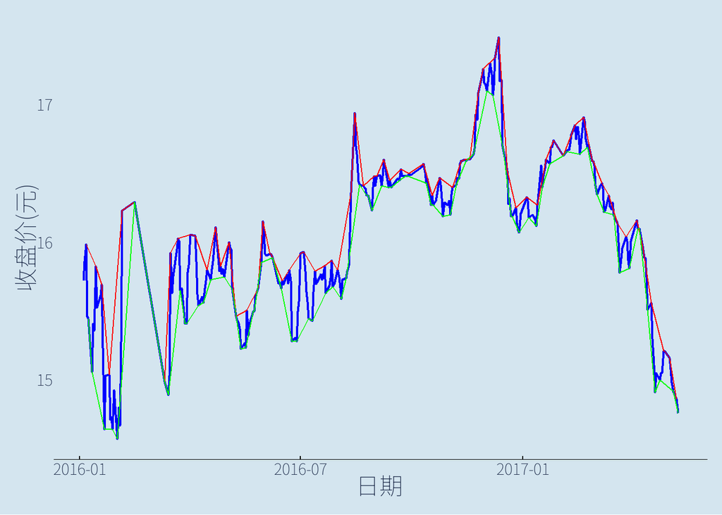

```r
ggplot()+
    geom_line(data =  data_65,
              aes(x = 日期,
                  y = `收盘价(元)`),
              color = "blue",
              linewidth = 0.8) +
    geom_line(data =  week_max,
              aes(x = 日期,
                  y = `收盘价(元)`),
              color = "red",
              linewidth = 0.4)  +
#再加条周最低线玩玩
    geom_line(data =  (data_65 %>% select(日期,`收盘价(元)`) %>%
                           group_by(年_周 = format(日期,'%Y-%W')) %>%
                           slice_min(`收盘价(元)`)),
              aes(x = 日期,
                  y = `收盘价(元)`),
              color = "green",
              linewidth = 0.4) +
    theme_chen()
```

# 73 将数据往后移动5天

不能简单的对整个数据直接lag(5)，这样日期也同时往后移动了，没有意义。

数据长宽转变一样，确定要移动位置的数据列后，再执行lag()函数

本例中，前三列不用移动，后面全部各列均需移动。 这可以用mutate()函数结合across()函数实现

```r
data_65 %>%
    mutate(across(-(1:3),
                  ~lag(.x,5)))
```

```
## # A tibble: 309 × 18
##    代码      简称  日期                `前收盘价(元)` `开盘价(元)` `最高价(元)`
##    <chr>     <chr> <dttm>                       <dbl>        <dbl>        <dbl>
##  1 600000.SH 浦发… 2016-01-04 00:00:00           NA           NA           NA
##  2 600000.SH 浦发… 2016-01-05 00:00:00           NA           NA           NA
##  3 600000.SH 浦发… 2016-01-06 00:00:00           NA           NA           NA
##  4 600000.SH 浦发… 2016-01-07 00:00:00           NA           NA           NA
##  5 600000.SH 浦发… 2016-01-08 00:00:00           NA           NA           NA
##  6 600000.SH 浦发… 2016-01-11 00:00:00           16.1         16.1         16.1
##  7 600000.SH 浦发… 2016-01-12 00:00:00           15.7         15.5         16.0
##  8 600000.SH 浦发… 2016-01-13 00:00:00           15.9         15.8         16.0
##  9 600000.SH 浦发… 2016-01-14 00:00:00           16.0         15.7         15.8
## 10 600000.SH 浦发… 2016-01-15 00:00:00           15.5         15.7         15.8
## # ℹ 299 more rows
## # ℹ 12 more variables: `最低价(元)` <dbl>, `收盘价(元)` <dbl>,
## #   `成交量(股)` <chr>, `成交金额(元)` <chr>, `涨跌(元)` <dbl>,
## #   `涨跌幅(%)` <dbl>, `均价(元)` <chr>, `换手率(%)` <dbl>,
## #   `A股流通市值(元)` <dbl>, `总市值(元)` <dbl>, `A股流通股本(股)` <dbl>,
## #   市盈率 <dbl>
```

# 74 将数据向前移动5天

与上题一样的逻辑，lag()函数变成lead函数即可。

```r
data_65 %>%
    mutate(across(-(1:3),
                  ~lead(.x,5)))
```

```
## # A tibble: 309 × 18
##    代码      简称  日期                `前收盘价(元)` `开盘价(元)` `最高价(元)`
##    <chr>     <chr> <dttm>                       <dbl>        <dbl>        <dbl>
##  1 600000.SH 浦发… 2016-01-04 00:00:00           15.4         15.2         15.4
##  2 600000.SH 浦发… 2016-01-05 00:00:00           15.1         15.2         15.5
##  3 600000.SH 浦发… 2016-01-06 00:00:00           15.4         15.5         15.8
##  4 600000.SH 浦发… 2016-01-07 00:00:00           15.4         15.0         15.9
##  5 600000.SH 浦发… 2016-01-08 00:00:00           15.8         15.7         16.0
##  6 600000.SH 浦发… 2016-01-11 00:00:00           15.5         15.4         15.9
##  7 600000.SH 浦发… 2016-01-12 00:00:00           15.6         15.7         15.8
##  8 600000.SH 浦发… 2016-01-13 00:00:00           15.7         15.6         15.6
##  9 600000.SH 浦发… 2016-01-14 00:00:00           15.2         15.2         15.4
## 10 600000.SH 浦发… 2016-01-15 00:00:00           14.6         14.9         15.1
## # ℹ 299 more rows
## # ℹ 12 more variables: `最低价(元)` <dbl>, `收盘价(元)` <dbl>,
## #   `成交量(股)` <chr>, `成交金额(元)` <chr>, `涨跌(元)` <dbl>,
## #   `涨跌幅(%)` <dbl>, `均价(元)` <chr>, `换手率(%)` <dbl>,
## #   `A股流通市值(元)` <dbl>, `总市值(元)` <dbl>, `A股流通股本(股)` <dbl>,
## #   市盈率 <dbl>
```

# 75 使用expending函数计算开盘价的移动窗口均值

这个就是做累计移动平均计算，就是计算截至到本行以来的平均值。使用cummean()函数

```r
data_65 %>%
    mutate(mean_value =cummean(`开盘价(元)`),
           .after = `开盘价(元)` )
```

```
## # A tibble: 309 × 19
##    代码      简称     日期                `前收盘价(元)` `开盘价(元)` mean_value
##    <chr>     <chr>    <dttm>                       <dbl>        <dbl>      <dbl>
##  1 600000.SH 浦发银行 2016-01-04 00:00:00           16.1         16.1       16.1
##  2 600000.SH 浦发银行 2016-01-05 00:00:00           15.7         15.5       15.8
##  3 600000.SH 浦发银行 2016-01-06 00:00:00           15.9         15.8       15.8
##  4 600000.SH 浦发银行 2016-01-07 00:00:00           16.0         15.7       15.8
##  5 600000.SH 浦发银行 2016-01-08 00:00:00           15.5         15.7       15.8
##  6 600000.SH 浦发银行 2016-01-11 00:00:00           15.4         15.2       15.7
##  7 600000.SH 浦发银行 2016-01-12 00:00:00           15.1         15.2       15.6
##  8 600000.SH 浦发银行 2016-01-13 00:00:00           15.4         15.5       15.6
##  9 600000.SH 浦发银行 2016-01-14 00:00:00           15.4         15.0       15.5
## 10 600000.SH 浦发银行 2016-01-15 00:00:00           15.8         15.7       15.5
## # ℹ 299 more rows
## # ℹ 13 more variables: `最高价(元)` <dbl>, `最低价(元)` <dbl>,
## #   `收盘价(元)` <dbl>, `成交量(股)` <chr>, `成交金额(元)` <chr>,
## #   `涨跌(元)` <dbl>, `涨跌幅(%)` <dbl>, `均价(元)` <chr>, `换手率(%)` <dbl>,
## #   `A股流通市值(元)` <dbl>, `总市值(元)` <dbl>, `A股流通股本(股)` <dbl>,
## #   市盈率 <dbl>
```

# 76 绘制上一题的移动均值与原始数据折线图

## 76.1 方法1：这种做法不可取，类似使用宽数据绘图的形式。

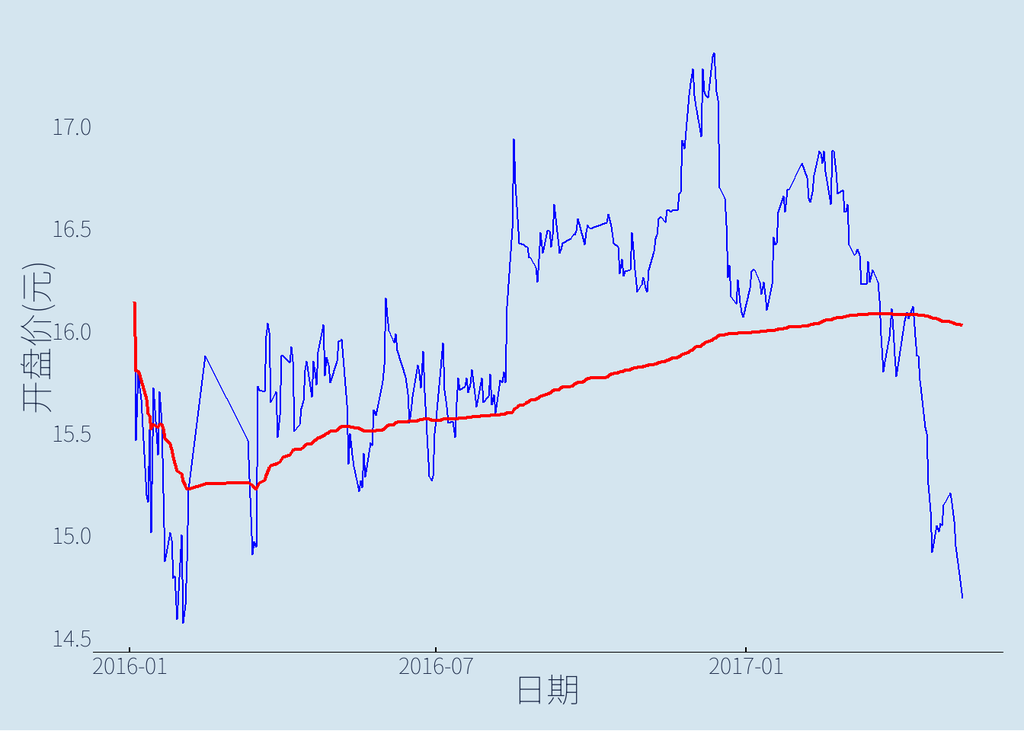

```r
ggplot()+
    geom_line(data =  data_65,
              aes(x = 日期,
                  y = `开盘价(元)`),
              color = "blue",
              linewidth = 0.4) +

    geom_line(data =  data_65 %>%
    mutate(mean_value =cummean(`开盘价(元)`),
           .after = `开盘价(元)` ),
              aes(x = 日期,
                  y = mean_value),
    color = "red",
    linewidth = 0.8) +
    theme_chen()
```

## 76.2 方法2：宽数据变长数据后再作图，合理的方法

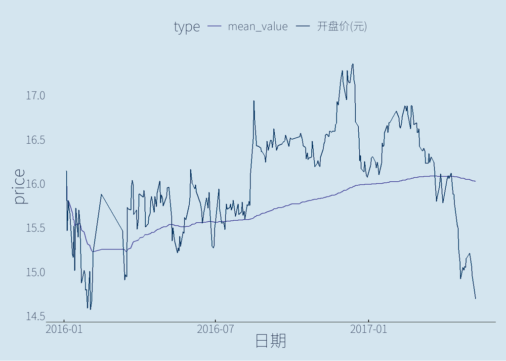

```r
data_65 %>%
    mutate(mean_value =cummean(`开盘价(元)`),
           .after = `开盘价(元)` ) %>%
    select(日期,
           `开盘价(元)`,
           mean_value) %>%
    pivot_longer(-1,
                 names_to = "type",
                 values_to = "price") %>%
    ggplot(aes(x = 日期,
               y = price))+
    geom_line( aes(color = type) )+
     scale_color_manual(values = palette[c(6,9)])+
    theme_chen()
```

# 77 计算布林指标

boll指标大意就是20日均值为中心线，然后上下两条线是这个中线加减一定sigma值的线。类似质量管理中SPC 管控里的上下控制限的逻辑。

## 77.1 方法1：自行计算

20日均线用前面自定义的函数；20日价格标准差自定义一个函数，如下

```r
sd_fun <- function(data, width){
   i  = length(data)
   if(width > i){
       return("数据不够，请增加数据")
   }
   k =width:i
   sd_value =c(rep(NA,width-1),
              map_vec(k,\(x) sd(data[(x-(width-1)):x])))
return( sd_value)
 }

data_65 %>%
    mutate(ma_20 = ma_fun(`收盘价(元)`,20),
           b_up = ma_20 + 2*sd_fun(`收盘价(元)`,20),
           b_bd = ma_20 - 2*sd_fun(`收盘价(元)`,20)) %>%
    select(ma_20,b_up,b_bd,everything()) %>%
    tail(3)
```

```
## # A tibble: 3 × 21
##   ma_20  b_up  b_bd 代码   简称  日期                `前收盘价(元)` `开盘价(元)`
##   <dbl> <dbl> <dbl> <chr>  <chr> <dttm>                       <dbl>        <dbl>
## 1  15.3  16.1  14.6 60000… 浦发… 2017-05-05 00:00:00           15.0         15.0
## 2  15.3  16.0  14.6 60000… 浦发… 2017-05-08 00:00:00           14.9         14.8
## 3  15.2  15.9  14.5 60000… 浦发… 2017-05-09 00:00:00           14.9         14.7
## # ℹ 13 more variables: `最高价(元)` <dbl>, `最低价(元)` <dbl>,
## #   `收盘价(元)` <dbl>, `成交量(股)` <chr>, `成交金额(元)` <chr>,
## #   `涨跌(元)` <dbl>, `涨跌幅(%)` <dbl>, `均价(元)` <chr>, `换手率(%)` <dbl>,
## #   `A股流通市值(元)` <dbl>, `总市值(元)` <dbl>, `A股流通股本(股)` <dbl>,
## #   市盈率 <dbl>
```

## 77.2 方法2：调包和函数计算:slider::slide_dbl()函数

和前面计算5日移动均值一样，可以选择各种包进行计算，比如slider包这个包。

```r
data_65 %>%
    mutate(ma_20 = slider::slide_dbl( `收盘价(元)`,
                                         mean,
                                         .before = 19,
                                         .complete = TRUE),
           sd =slider::slide_dbl( `收盘价(元)`,
                                         sd,
                                         .before = 19,
                                         .complete = TRUE),
           b_up = ma_20 + 2*sd,
           b_bd = ma_20 - 2*sd)%>%
    select(ma_20,b_up,b_bd,everything()) %>%
    tail(3)
```

```
## # A tibble: 3 × 22
##   ma_20  b_up  b_bd 代码   简称  日期                `前收盘价(元)` `开盘价(元)`
##   <dbl> <dbl> <dbl> <chr>  <chr> <dttm>                       <dbl>        <dbl>
## 1  15.3  16.1  14.6 60000… 浦发… 2017-05-05 00:00:00           15.0         15.0
## 2  15.3  16.0  14.6 60000… 浦发… 2017-05-08 00:00:00           14.9         14.8
## 3  15.2  15.9  14.5 60000… 浦发… 2017-05-09 00:00:00           14.9         14.7
## # ℹ 14 more variables: `最高价(元)` <dbl>, `最低价(元)` <dbl>,
## #   `收盘价(元)` <dbl>, `成交量(股)` <chr>, `成交金额(元)` <chr>,
## #   `涨跌(元)` <dbl>, `涨跌幅(%)` <dbl>, `均价(元)` <chr>, `换手率(%)` <dbl>,
## #   `A股流通市值(元)` <dbl>, `总市值(元)` <dbl>, `A股流通股本(股)` <dbl>,
## #   市盈率 <dbl>, sd <dbl>
```

## 77.3 方法3：调包和函数计算:TTR::runMean()函数

搞和金融相关的事情，不用和金融相关的包，有点说不过去。

```r
 data_65 %>%
    mutate(ma_20 = TTR::runMean ( `收盘价(元)`, 20),
           b_up = ma_20 + 2*TTR::runSD(`收盘价(元)`,20),
           b_bd = ma_20 - 2*TTR::runSD(`收盘价(元)`,20))%>%
    select(ma_20,b_up,b_bd,everything()) %>%
    tail(3)
```

```
## # A tibble: 3 × 21
##   ma_20  b_up  b_bd 代码   简称  日期                `前收盘价(元)` `开盘价(元)`
##   <dbl> <dbl> <dbl> <chr>  <chr> <dttm>                       <dbl>        <dbl>
## 1  15.3  16.1  14.6 60000… 浦发… 2017-05-05 00:00:00           15.0         15.0
## 2  15.3  16.0  14.6 60000… 浦发… 2017-05-08 00:00:00           14.9         14.8
## 3  15.2  15.9  14.5 60000… 浦发… 2017-05-09 00:00:00           14.9         14.7
## # ℹ 13 more variables: `最高价(元)` <dbl>, `最低价(元)` <dbl>,
## #   `收盘价(元)` <dbl>, `成交量(股)` <chr>, `成交金额(元)` <chr>,
## #   `涨跌(元)` <dbl>, `涨跌幅(%)` <dbl>, `均价(元)` <chr>, `换手率(%)` <dbl>,
## #   `A股流通市值(元)` <dbl>, `总市值(元)` <dbl>, `A股流通股本(股)` <dbl>,
## #   市盈率 <dbl>
```

## 77.4 方法4：调包和函数计算:tidyquant:: tq_mutate()函数

使用tidyquant 包 tq_mutate()函数，与自编函数( 把20天均线以及上下限的获取写在一个函数里，批量滚动获取即可)

```r
 getboll <- function(x,na.rm = TRUE){
    m  <- mean(x, na.rm = na.rm)
    s  <- sd(x, na.rm = na.rm)
    hi <- m + 2*s
    lo <- m - 2*s
    result <- c(ma_20 =m,
                b_up= hi,
                b_bd =lo)
    return(result)
 }

data_65 %>%
     tidyquant:: tq_mutate(select ="收盘价(元)",
                mutate_fun = rollapply,
                width = 20,
                align = "right",
                by.column = FALSE,
                FUN  =  getboll)%>%
    select(ma_20,b_up,b_bd,everything()) %>%
    tail(3)
```

```
## # A tibble: 3 × 21
##   ma_20  b_up  b_bd 代码   简称  日期                `前收盘价(元)` `开盘价(元)`
##   <dbl> <dbl> <dbl> <chr>  <chr> <dttm>                       <dbl>        <dbl>
## 1  15.3  16.1  14.6 60000… 浦发… 2017-05-05 00:00:00           15.0         15.0
## 2  15.3  16.0  14.6 60000… 浦发… 2017-05-08 00:00:00           14.9         14.8
## 3  15.2  15.9  14.5 60000… 浦发… 2017-05-09 00:00:00           14.9         14.7
## # ℹ 13 more variables: `最高价(元)` <dbl>, `最低价(元)` <dbl>,
## #   `收盘价(元)` <dbl>, `成交量(股)` <chr>, `成交金额(元)` <chr>,
## #   `涨跌(元)` <dbl>, `涨跌幅(%)` <dbl>, `均价(元)` <chr>, `换手率(%)` <dbl>,
## #   `A股流通市值(元)` <dbl>, `总市值(元)` <dbl>, `A股流通股本(股)` <dbl>,
## #   市盈率 <dbl>
```

# 78 计算布林线并绘制

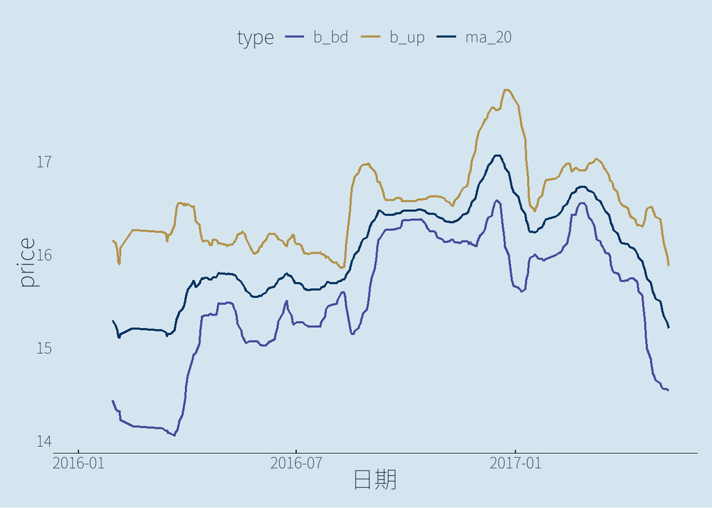

```r
  data_65 %>%
      tidyquant:: tq_mutate(select ="收盘价(元)",
                mutate_fun = rollapply,
                width = 20,
                align = "right",
                by.column = FALSE,
                FUN  =  getboll) %>%
    select(日期, ma_20,b_up,b_bd) %>%
    pivot_longer(-1,
                 names_to = "type",
                 values_to = "price") %>%
        ggplot(aes(x = 日期,
                   y = price,
                   group = type,
                   color = type)) +
    geom_line(linewidth = 0.8) +
 scale_color_manual(values = palette[c(6,7,9)])+
    theme_chen()
```

# 79 查看包的版本

map()可真是个好用的函数。咱就是说，一言不合就map。

```r
c("tidyverse","zoo","DescTools") %>%
    map(packageVersion)
```

```
## [[1]]
## [1] '2.0.0'
##
## [[2]]
## [1] '1.8.12'
##
## [[3]]
## [1] '0.99.50'
```

# 80 从数组创建DataFrame

```r
options(digits=1)
set.seed(1234)

tb1 <- sample(20:300,20) %>%
 array(dim = 20) %>%
 as_tibble( )

 head(tb1)
```

```
## # A tibble: 6 × 1
##   value
##   <int>
## 1   120
## 2   130
## 3   152
## 4   117
## 5   122
## 6   233
```

# 81 生成20个0-100固定步长的数

```r
 tb2 <- seq(0,99,5) %>%
    as_tibble()
head(tb2)
```

```
## # A tibble: 6 × 1
##   value
##   <dbl>
## 1     0
## 2     5
## 3    10
## 4    15
## 5    20
## 6    25
```

84.生成20个指定分布(如标准正态分布)的数

```r
tb3 <- rnorm(n = 20,mean = 0,sd = 1) %>%
    as_tibble()
head(tb3)
```

```
## # A tibble: 6 × 1
##    value
##    <dbl>
## 1  0.134
## 2 -0.491
## 3 -0.441
## 4  0.460
## 5 -0.694
## 6 -1.45
```

# 82 将df1，df2，df3按照行合并为新DataFrame

## 82.1 方法1:base R 包函数 rbind()

```r
rbind(tb1,tb2,tb3) %>%
    head()
```

```
## # A tibble: 6 × 1
##   value
##   <dbl>
## 1   120
## 2   130
## 3   152
## 4   117
## 5   122
## 6   233
```

## 82.2 方法2:bind_rows()函数

```r
bind_rows(tb1,tb2,tb3) %>%
    head()
```

```
## # A tibble: 6 × 1
##   value
##   <dbl>
## 1   120
## 2   130
## 3   152
## 4   117
## 5   122
## 6   233
```

# 83 将df1，df2，df3按照列合并为新DataFrame

## 83.1 方法1:base R 包函数 cbind()

```r
df_combine <- cbind(tb1,tb2,tb3)
 head(df_combine)
```

```
##   value value value
## 1   120     0   0.1
## 2   130     5  -0.5
## 3   152    10  -0.4
## 4   117    15   0.5
## 5   122    20  -0.7
## 6   233    25  -1.4
```

## 83.2 方法2:bind_cols()函数

```r
 bind_cols(tb1,tb2,tb3) %>%
     head()# tidyverse 系列包函数
```

```
## # A tibble: 6 × 3
##   value...1 value...2 value...3
##       <int>     <dbl>     <dbl>
## 1       120         0     0.134
## 2       130         5    -0.491
## 3       152        10    -0.441
## 4       117        15     0.460
## 5       122        20    -0.694
## 6       233        25    -1.45
```

# 84 查看df所有数据的最小值、25%分位数、中位数、75%分位数、最大值

使用summary()函数

```r
#按列查看
df_combine %>%
    summary()
```

```
##      value         value        value
##  Min.   : 23   Min.   : 0   Min.   :-2.2
##  1st Qu.:106   1st Qu.:24   1st Qu.:-1.1
##  Median :126   Median :48   Median :-0.5
##  Mean   :144   Mean   :48   Mean   :-0.6
##  3rd Qu.:196   3rd Qu.:71   3rd Qu.:-0.2
##  Max.   :289   Max.   :95   Max.   : 1.1
```

```r
# 查看全体数据
df_combine %>%
    unlist() %>%
    summary()
```

```
##    Min. 1st Qu.  Median    Mean 3rd Qu.    Max.
##      -2       0      42      64     101     289
```

# 85 修改列名为col1,col2,col3

## 85.1 方法1：set_names()函数

```r
df_88 <- set_names(df_combine,nm = str_c("col",1:3))
```

## 85.2 方法2：names()函数

```r
names(df_combine) <- str_c("col",1:3)
df_combine %>%
    head(3)
```

```
##   col1 col2 col3
## 1  120    0  0.1
## 2  130    5 -0.5
## 3  152   10 -0.4
```

## 85.3 方法3：tibble()函数name_repair 参数

```r
df_combine %>%
    as_tibble(.name_repair = ~ str_c("col",1:3))
```

```
## # A tibble: 20 × 3
##     col1  col2    col3
##    <int> <dbl>   <dbl>
##  1   120     0  0.134
##  2   130     5 -0.491
##  3   152    10 -0.441
##  4   117    15  0.460
##  5   122    20 -0.694
##  6   233    25 -1.45
##  7   109    30  0.575
##  8    98    35 -1.02
##  9   289    40 -0.0151
## 10   203    45 -0.936
## 11    81    50  1.10
## 12    23    55 -0.476
## 13   168    60 -0.709
## 14    59    65 -0.501
## 15   231    70 -1.63
## 16   214    75 -1.17
## 17   112    80 -2.18
## 18   141    85 -1.34
## 19    85    90 -0.294
## 20   194    95 -0.466
```

# 86 提取第一列中不在第二列出现的数字

这题本质感觉是比较与匹配的逻辑。

## 86.1 方法1 生硬的理解字面意思，第一列中不在第二列出现的数字

```r
df_combine$col1 [!df_combine$col1%in% df_combine$col2 ]
```

```
##  [1] 120 130 152 117 122 233 109  98 289 203  81  23 168  59 231 214 112 141 194
```

```r
# 用简单示例理解
a = 1:10
b =5:15
# 显然，5到10在a和b里
a[!a%in%b]
```

```
## [1] 1 2 3 4
```

```r
# 这里的结果就是1,2,3,4了
```

## 86.2 方法2：setdiff()函数就是直接一个函数

```r
setdiff(a,b)
```

```
## [1] 1 2 3 4
```

```r
setdiff(b,a)
```

```
## [1] 11 12 13 14 15
```

## 86.3 方法3：如果是数据框这种类型，还可以用anti_join()函数来实现

```r
as_tibble(a) %>%
    anti_join(as_tibble(b))
```

```
## # A tibble: 4 × 1
##   value
##   <int>
## 1     1
## 2     2
## 3     3
## 4     4
```

```r
tb1 %>%
    anti_join(tb2)
```

```
## # A tibble: 19 × 1
##    value
##    <int>
##  1   120
##  2   130
##  3   152
##  4   117
##  5   122
##  6   233
##  7   109
##  8    98
##  9   289
## 10   203
## 11    81
## 12    23
## 13   168
## 14    59
## 15   231
## 16   214
## 17   112
## 18   141
## 19   194
```

# 87 提取第一列和第二列出现频率最高的三个数字

```r
df_combine %>%
    select(col1,col2) %>%
    unlist() %>%
    as_tibble() %>%
   summarise(n =n(),
             .by = value) %>%
    slice_max(n,n =3,
              with_ties = FALSE) # 并列最多的数字太多，这里选择with_ties = false, 就只出现3个，否则会全部显示。
```

```
## # A tibble: 3 × 2
##   value     n
##   <dbl> <int>
## 1    85     2
## 2   120     1
## 3   130     1
```

# 88 提取第一列中可以整除5的数字位置

## 88.1 方法1： which()大法

```r
which(df_combine$col1 %% 5 == 0)
```

```
## [1]  1  2 19
```

## 88.2 方法2： filter()函数

```r
 df_combine %>%
     rowid_to_column() %>%
     filter(col1 %%5 ==0)  %>%
     select(rowid)
```

```
##   rowid
## 1     1
## 2     2
## 3    19
```

# 89 计算第一列数字前一个与后一个的差值

```r
df_combine %>%
    mutate(diff_1 =c(NA,
                     diff(col1,1,1)),
           .after = col1)
```

```
##    col1 diff_1 col2  col3
## 1   120     NA    0  0.13
## 2   130     10    5 -0.49
## 3   152     22   10 -0.44
## 4   117    -35   15  0.46
## 5   122      5   20 -0.69
## 6   233    111   25 -1.45
## 7   109   -124   30  0.57
## 8    98    -11   35 -1.02
## 9   289    191   40 -0.02
## 10  203    -86   45 -0.94
## 11   81   -122   50  1.10
## 12   23    -58   55 -0.48
## 13  168    145   60 -0.71
## 14   59   -109   65 -0.50
## 15  231    172   70 -1.63
## 16  214    -17   75 -1.17
## 17  112   -102   80 -2.18
## 18  141     29   85 -1.34
## 19   85    -56   90 -0.29
## 20  194    109   95 -0.47
```

# 90 将col1,col2,col3三列顺序颠倒

## 90.1 方法1：select()函数

与列处理相关，第一时间想到select()函数

```r
 df_combine %>%
    select(str_c("col",3:1))
```

```
##     col3 col2 col1
## 1   0.13    0  120
## 2  -0.49    5  130
## 3  -0.44   10  152
## 4   0.46   15  117
## 5  -0.69   20  122
## 6  -1.45   25  233
## 7   0.57   30  109
## 8  -1.02   35   98
## 9  -0.02   40  289
## 10 -0.94   45  203
## 11  1.10   50   81
## 12 -0.48   55   23
## 13 -0.71   60  168
## 14 -0.50   65   59
## 15 -1.63   70  231
## 16 -1.17   75  214
## 17 -2.18   80  112
## 18 -1.34   85  141
## 19 -0.29   90   85
## 20 -0.47   95  194
```

# 91 方法2：relocate()函数

涉及到列位置，顺序，可以考虑使用relocate()函数

```r
df_combine %>%
    relocate(col2,.before = col1) %>%
    relocate(col3,.before = col2)
```

```
##     col3 col2 col1
## 1   0.13    0  120
## 2  -0.49    5  130
## 3  -0.44   10  152
## 4   0.46   15  117
## 5  -0.69   20  122
## 6  -1.45   25  233
## 7   0.57   30  109
## 8  -1.02   35   98
## 9  -0.02   40  289
## 10 -0.94   45  203
## 11  1.10   50   81
## 12 -0.48   55   23
## 13 -0.71   60  168
## 14 -0.50   65   59
## 15 -1.63   70  231
## 16 -1.17   75  214
## 17 -2.18   80  112
## 18 -1.34   85  141
## 19 -0.29   90   85
## 20 -0.47   95  194
```

# 92 提取第一列位置在1,10,15的数字

这是列和行组合应用，列：select,行：filter,slice这些

## 92.1 方法1：select() + slice()

```r
# 方法1：slice()
df_combine %>%
    select(col1) %>%
    slice(1,10,15)
```

```
##   col1
## 1  120
## 2  203
## 3  231
```

## 92.2 方法2：rowid_to_column()+filter()+ select()

```r
 df_combine %>%
    rowid_to_column() %>%
     filter(rowid %in% c(1,10,15))  %>%
     select(col1)
```

```
##   col1
## 1  120
## 2  203
## 3  231
```

## 92.3 方法3：filter()+row_number()+ select()

```r
 df_combine %>%
     filter(row_number()%in% c(1,10,15)) %>%
     select(col1)
```

```
##   col1
## 1  120
## 2  203
## 3  231
```

# 93 找第一列的局部最大值位置,即比它前一个与后一个数字的都大的数字

lag()和lead()函数解决这个问题

```r
df_combine %>%
    mutate(max_mark = if_else((col1-lag(col1))>0,
                                if_else((col1-lead(col1))>0,
                                         1,
                                         0),
                                        0)) %>%
    filter(max_mark ==1)
```

```
##   col1 col2  col3 max_mark
## 1  152   10 -0.44        1
## 2  233   25 -1.45        1
## 3  289   40 -0.02        1
## 4  168   60 -0.71        1
## 5  231   70 -1.63        1
## 6  141   85 -1.34        1
```

- 同样的，肯定就有局部最小值,求最小值并把他们同时在一张图上显示出来

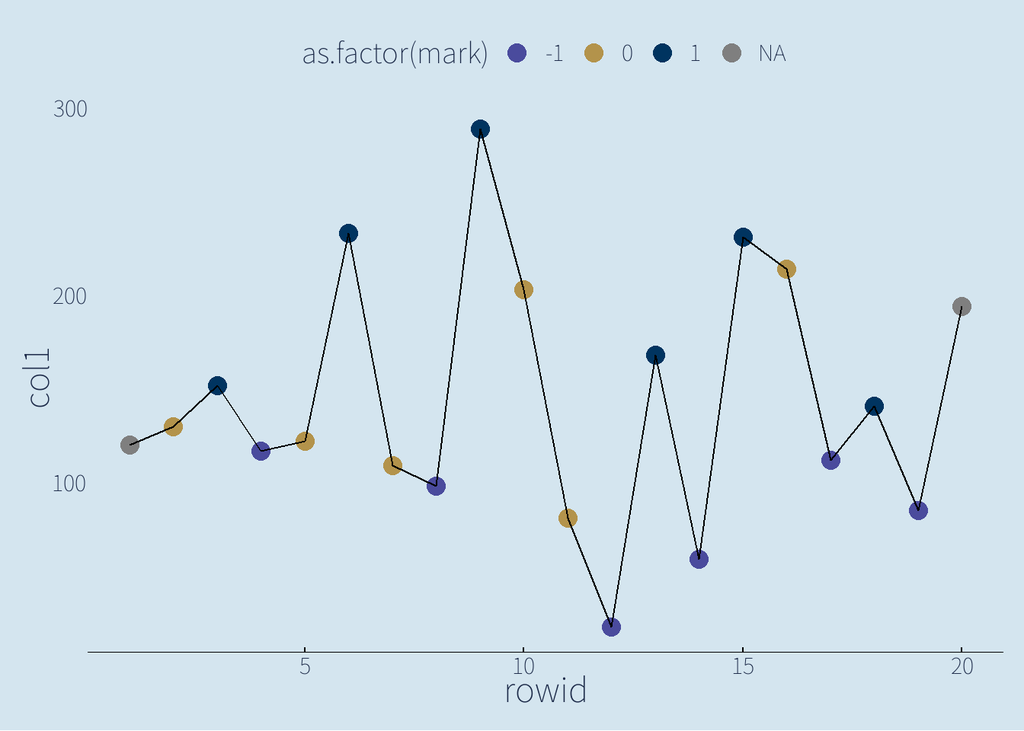

```r
lag_val <- df_combine$col1-lag(df_combine$col1)
lead_val <- df_combine$col1-lead(df_combine$col1)

df_combine %>%
    mutate(mark =  if_else(lead_val*lag_val <= 0,
                           0,
                          if_else(lag_val > 0,
                                  1,
                                  -1)
                           )
           )%>%
    rowid_to_column() %>%

    select(rowid,col1,mark) %>%
    ggplot(aes(x = rowid,y = col1))+
    geom_point(aes(color = as.factor(mark)),size = 4)+
    geom_line()+
    theme(panel.background = element_blank())+
         scale_color_manual(values = palette[c(6,7,9,16)])+
    theme_chen()
```

# 94 按行计算df的每一行均值

使用rowwise函数

```r
df_combine %>%
    rowwise() %>%
    mutate(row_mean = mean(c_across(col1:col3)
                           )
           )
```

```
## # A tibble: 20 × 4
## # Rowwise:
##     col1  col2    col3 row_mean
##    <int> <dbl>   <dbl>    <dbl>
##  1   120     0  0.134      40.0
##  2   130     5 -0.491      44.8
##  3   152    10 -0.441      53.9
##  4   117    15  0.460      44.2
##  5   122    20 -0.694      47.1
##  6   233    25 -1.45       85.5
##  7   109    30  0.575      46.5
##  8    98    35 -1.02       44.0
##  9   289    40 -0.0151    110.
## 10   203    45 -0.936      82.4
## 11    81    50  1.10       44.0
## 12    23    55 -0.476      25.8
## 13   168    60 -0.709      75.8
## 14    59    65 -0.501      41.2
## 15   231    70 -1.63       99.8
## 16   214    75 -1.17       95.9
## 17   112    80 -2.18       63.3
## 18   141    85 -1.34       74.9
## 19    85    90 -0.294      58.2
## 20   194    95 -0.466      96.2
```

```r
# 或者
df_combine %>%
    rowwise() %>%
    mutate(row_mean = mean(c(col1,col2,col3)
                           )
    )
```

```
## # A tibble: 20 × 4
## # Rowwise:
##     col1  col2    col3 row_mean
##    <int> <dbl>   <dbl>    <dbl>
##  1   120     0  0.134      40.0
##  2   130     5 -0.491      44.8
##  3   152    10 -0.441      53.9
##  4   117    15  0.460      44.2
##  5   122    20 -0.694      47.1
##  6   233    25 -1.45       85.5
##  7   109    30  0.575      46.5
##  8    98    35 -1.02       44.0
##  9   289    40 -0.0151    110.
## 10   203    45 -0.936      82.4
## 11    81    50  1.10       44.0
## 12    23    55 -0.476      25.8
## 13   168    60 -0.709      75.8
## 14    59    65 -0.501      41.2
## 15   231    70 -1.63       99.8
## 16   214    75 -1.17       95.9
## 17   112    80 -2.18       63.3
## 18   141    85 -1.34       74.9
## 19    85    90 -0.294      58.2
## 20   194    95 -0.466      96.2
```

# 95 对第二列计算移动平均值,假设步长为4

前面的题目中已出现过，且用多种方法进行了求解。

```r
df_combine %>%
   mutate(average_4 = zoo::rollmean(col2,
                                    4,
                                    align = "right",
                                    fill = NA))
```

```
##    col1 col2  col3 average_4
## 1   120    0  0.13        NA
## 2   130    5 -0.49        NA
## 3   152   10 -0.44        NA
## 4   117   15  0.46         8
## 5   122   20 -0.69        12
## 6   233   25 -1.45        18
## 7   109   30  0.57        22
## 8    98   35 -1.02        28
## 9   289   40 -0.02        32
## 10  203   45 -0.94        38
## 11   81   50  1.10        42
## 12   23   55 -0.48        48
## 13  168   60 -0.71        52
## 14   59   65 -0.50        58
## 15  231   70 -1.63        62
## 16  214   75 -1.17        68
## 17  112   80 -2.18        72
## 18  141   85 -1.34        78
## 19   85   90 -0.29        82
## 20  194   95 -0.47        88
```

# 96 将数据按照第三列值的大小升序排列

```r
df_combine %>%
arrange(col3)
```

```
##    col1 col2  col3
## 1   112   80 -2.18
## 2   231   70 -1.63
## 3   233   25 -1.45
## 4   141   85 -1.34
## 5   214   75 -1.17
## 6    98   35 -1.02
## 7   203   45 -0.94
## 8   168   60 -0.71
## 9   122   20 -0.69
## 10   59   65 -0.50
## 11  130    5 -0.49
## 12   23   55 -0.48
## 13  194   95 -0.47
## 14  152   10 -0.44
## 15   85   90 -0.29
## 16  289   40 -0.02
## 17  120    0  0.13
## 18  117   15  0.46
## 19  109   30  0.57
## 20   81   50  1.10
```

# 97 将第一列大于50的数字修改为’高’

```r
df_combine %>%
    mutate(col =ifelse(col1 > 150,
                       "高",
                       col1)) # 改为大于150的
```

```
##    col1 col2  col3 col
## 1   120    0  0.13 120
## 2   130    5 -0.49 130
## 3   152   10 -0.44  高
## 4   117   15  0.46 117
## 5   122   20 -0.69 122
## 6   233   25 -1.45  高
## 7   109   30  0.57 109
## 8    98   35 -1.02  98
## 9   289   40 -0.02  高
## 10  203   45 -0.94  高
## 11   81   50  1.10  81
## 12   23   55 -0.48  23
## 13  168   60 -0.71  高
## 14   59   65 -0.50  59
## 15  231   70 -1.63  高
## 16  214   75 -1.17  高
## 17  112   80 -2.18 112
## 18  141   85 -1.34 141
## 19   85   90 -0.29  85
## 20  194   95 -0.47  高
```

还有很多种方法，比较简单的内容，不多重复。

**补充一点，tidyverse系列的if_else()函数不支持类似写法，它严格要求不同情形下的内容同样的字符类型。**

# 98 计算第一列与第二列之间的欧式距离

```r
df_combine %>%
    select(col1,col2) %>%
    # as.matrix() %>%
    t() %>%
stats::dist(method = "euclidean")
```

```
##      col1
## col2  533
```

# 99 从CSV文件中读取指定数据:从数据1中的前10行中读取positionName, salary两列

# 100 方法1 readr::read_csv()函数

```r
 df_1 <- readr::read_csv("./data/数据1.csv",
          col_select = c( positionName , salary),
          n_max = 10,
          locale = locale(encoding = "gbk"),
          show_col_types = FALSE)
```

# 101 方法2 base R read.csv()函数

```r
 read.csv("./data/数据1.csv",
          nrows = 10,
          header = TRUE,
          fileEncoding = "gbk") %>%
     select(c(positionName,salary ))
```

```
##      positionName salary
## 1        数据分析  37500
## 2        数据建模  15000
## 3        数据分析   3500
## 4        数据分析  45000
## 5        数据分析  30000
## 6        数据分析  50000
## 7        数据分析  30000
## 8  数据建模工程师  35000
## 9    数据分析专家  60000
## 10     数据分析师  40000
```

补充：read.csv(),read.csv2(),read_csv(),read_csv2(),这几个常用函数看上去简单，其实，里边的门道还是挺多的；值得花时间好好琢磨。